# Project: Identify Customer Segments

In this project, you will apply unsupervised learning techniques to identify segments of the population that form the core customer base for a mail-order sales company in Germany. These segments can then be used to direct marketing campaigns towards audiences that will have the highest expected rate of returns. The data that you will use has been provided by our partners at Bertelsmann Arvato Analytics, and represents a real-life data science task.

This notebook will help you complete this task by providing a framework within which you will perform your analysis steps. In each step of the project, you will see some text describing the subtask that you will perform, followed by one or more code cells for you to complete your work. **Feel free to add additional code and markdown cells as you go along so that you can explore everything in precise chunks.** The code cells provided in the base template will outline only the major tasks, and will usually not be enough to cover all of the minor tasks that comprise it.

It should be noted that while there will be precise guidelines on how you should handle certain tasks in the project, there will also be places where an exact specification is not provided. **There will be times in the project where you will need to make and justify your own decisions on how to treat the data.** These are places where there may not be only one way to handle the data. In real-life tasks, there may be many valid ways to approach an analysis task. One of the most important things you can do is clearly document your approach so that other scientists can understand the decisions you've made.

At the end of most sections, there will be a Markdown cell labeled **Discussion**. In these cells, you will report your findings for the completed section, as well as document the decisions that you made in your approach to each subtask. **Your project will be evaluated not just on the code used to complete the tasks outlined, but also your communication about your observations and conclusions at each stage.**

```python
# import libraries here; add more as necessary
import numpy as np
import pandas as pd
import matplotlib.pyplot as plt
import seaborn as sns
import math
from sklearn.cluster import KMeans

from scipy.spatial.distance import cdist
from scipy.stats import itemfreq
from mpl_toolkits.mplot3d import Axes3D

from sklearn.preprocessing import StandardScaler, Imputer
from sklearn.decomposition import PCA

from pprint import pprint

# magic word for producing visualizations in notebook
%matplotlib inline
```

### Step 0: Load the Data

Each row of the demographics files represents a single person, but also includes information outside of individuals, including information about their household, building, and neighborhood. You will use this information to cluster the general population into groups with similar demographic properties. Then, you will see how the people in the customers dataset fit into those created clusters. The hope here is that certain clusters are over-represented in the customers data, as compared to the general population; those over-represented clusters will be assumed to be part of the core userbase. This information can then be used for further applications, such as targeting for a marketing campaign.

To start off with, load in the demographics data for the general population into a pandas DataFrame, and do the same for the feature attributes summary. Note for all of the `.csv` data files in this project: they're semicolon (`;`) delimited, so you'll need an additional argument in your [`read_csv()`](https://pandas.pydata.org/pandas-docs/stable/generated/pandas.read_csv.html) call to read in the data properly. Also, considering the size of the main dataset, it may take some time for it to load completely.

Once the dataset is loaded, it's recommended that you take a little bit of time just browsing the general structure of the dataset and feature summary file. You'll be getting deep into the innards of the cleaning in the first major step of the project, so gaining some general familiarity can help you get your bearings.

```python
# Load in the general demographics data.
azdias = pd.read_csv('Udacity_AZDIAS_Subset.csv',delimiter=';')
azdias_org=azdias.copy()
# Load in the feature summary file.
feat_info = pd.read_csv('AZDIAS_Feature_Summary.csv',delimiter=';')
feat_info_org=feat_info.copy()
feat_info.set_index('attribute',inplace=True)
feat_info['columns'] = feat_info.index
```

```python
# Check the structure of the data after it's loaded (e.g. print the number of
# rows and columns, print the first few rows).
print(azdias.shape)
#print(azdias.head())
print(azdias.describe)
azdias.info(verbose=True)
```

```
(891221, 85)
<bound method NDFrame.describe of         AGER_TYP  ALTERSKATEGORIE_GROB  ANREDE_KZ  CJT_GESAMTTYP  \
0             -1                     2          1            2.0
1             -1                     1          2            5.0
2             -1                     3          2            3.0
3              2                     4          2            2.0
4             -1                     3          1            5.0
5              3                     1          2            2.0
6             -1                     2          2            5.0
7             -1                     1          1            3.0
8             -1                     3          1            3.0
9             -1                     3          2            4.0
10             0                     3          2            1.0
11            -1                     2          1            6.0
12            -1                     3          1            6.0
```

[output cut: 392 more lines]

```python
print(feat_info.shape)
#print(feat_info.head())
print(feat_info.describe)
feat_info.info(verbose=True)
```

```
(85, 4)
<bound method NDFrame.describe of                       information_level         type missing_or_unknown  \
attribute
AGER_TYP                         person  categorical             [-1,0]
ALTERSKATEGORIE_GROB             person      ordinal           [-1,0,9]
ANREDE_KZ                        person  categorical             [-1,0]
CJT_GESAMTTYP                    person  categorical                [0]
FINANZ_MINIMALIST                person      ordinal               [-1]
FINANZ_SPARER                    person      ordinal               [-1]
FINANZ_VORSORGER                 person      ordinal               [-1]
FINANZ_ANLEGER                   person      ordinal               [-1]
FINANZ_UNAUFFAELLIGER            person      ordinal               [-1]
FINANZ_HAUSBAUER                 person      ordinal               [-1]
FINANZTYP                        person  categorical               [-1]
GEBURTSJAHR                      person      numeric                [0]
GFK_URLAUBERTYP                  person  categorical                 []
GREEN_AVANTGARDE                 person  categorical                 []
HEALTH_TYP                       person      ordinal             [-1,0]
LP_LEBENSPHASE_FEIN              person        mixed                [0]
LP_LEBENSPHASE_GROB              person        mixed                [0]
LP_FAMILIE_FEIN                  person  categorical                [0]
LP_FAMILIE_GROB                  person  categorical                [0]
LP_STATUS_FEIN                   person  categorical                [0]
LP_STATUS_GROB                   person  categorical                [0]
NATIONALITAET_KZ                 person  categorical             [-1,0]
PRAEGENDE_JUGENDJAHRE            person        mixed             [-1,0]
RETOURTYP_BK_S                   person      ordinal                [0]
SEMIO_SOZ                        person      ordinal             [-1,9]
SEMIO_FAM                        person      ordinal             [-1,9]
SEMIO_REL                        person      ordinal             [-1,9]
SEMIO_MAT                        person      ordinal             [-1,9]
SEMIO_VERT                       person      ordinal             [-1,9]
SEMIO_LUST                       person      ordinal             [-1,9]
...                                 ...          ...                ...
OST_WEST_KZ                    building  categorical               [-1]
WOHNLAGE                       building        mixed               [-1]
CAMEO_DEUG_2015           microcell_rr4  categorical             [-1,X]
CAMEO_DEU_2015            microcell_rr4  categorical               [XX]
CAMEO_INTL_2015           microcell_rr4        mixed            [-1,XX]
KBA05_ANTG1               microcell_rr3      ordinal               [-1]
```

[output cut: 84 more lines]

```
PLZ8_GBZ                            PLZ8_GBZ
ARBEIT                                ARBEIT
ORTSGR_KLS9                      ORTSGR_KLS9
RELAT_AB                            RELAT_AB

[85 rows x 4 columns]>
<class 'pandas.core.frame.DataFrame'>
Index: 85 entries, AGER_TYP to RELAT_AB
Data columns (total 4 columns):
information_level     85 non-null object
type                  85 non-null object
missing_or_unknown    85 non-null object
columns               85 non-null object
dtypes: object(4)
memory usage: 3.3+ KB
```

> **Tip**: Add additional cells to keep everything in reasonably-sized chunks! Keyboard shortcut `esc --> a` (press escape to enter command mode, then press the 'A' key) adds a new cell before the active cell, and `esc --> b` adds a new cell after the active cell. If you need to convert an active cell to a markdown cell, use `esc --> m` and to convert to a code cell, use `esc --> y`.

## Step 1: Preprocessing

### Step 1.1: Assess Missing Data

The feature summary file contains a summary of properties for each demographics data column. You will use this file to help you make cleaning decisions during this stage of the project. First of all, you should assess the demographics data in terms of missing data. Pay attention to the following points as you perform your analysis, and take notes on what you observe. Make sure that you fill in the **Discussion** cell with your findings and decisions at the end of each step that has one!

#### Step 1.1.1: Convert Missing Value Codes to NaNs

The fourth column of the feature attributes summary (loaded in above as `feat_info`) documents the codes from the data dictionary that indicate missing or unknown data. While the file encodes this as a list (e.g. `[-1,0]`), this will get read in as a string object. You'll need to do a little bit of parsing to make use of it to identify and clean the data. Convert data that matches a 'missing' or 'unknown' value code into a numpy NaN value. You might want to see how much data takes on a 'missing' or 'unknown' code, and how much data is naturally missing, as a point of interest.

**As one more reminder, you are encouraged to add additional cells to break up your analysis into manageable chunks.**

```python
# Identify missing or unknown data values and convert them to NaNs.
def convert_missing(strings):
    missing_vals={}
    lambda_conv =lambda x : x[1:-1].split(',')
    result = lambda_conv(strings)
    for i in result:
        if i.replace('-','').isnumeric():
            missing_vals[int(i)]=np.nan
        if i.isalpha():
            missing_vals[str(i)]=np.nan
    return missing_vals
```

```python
def get_missing_feats_dict_from_feats_info(feat_info):
    m_vals = feat_info[['attribute','missing_or_unknown']].copy()
    m_vals = m_vals.query('missing_or_unknown !="[]"')
    m_vals.missing_or_unknown = m_vals.missing_or_unknown.apply(convert_missing)
    m_dict = {i[0] : i[1] for i in m_vals.itertuples(index=False)}
    return m_dict
```

```python
m_dict = get_missing_feats_dict_from_feats_info(feat_info_org)
for k,v in m_dict.items():
    azdias[k].replace(v,inplace=True)

azdias.head()
```

|  | AGER_TYP | ALTERSKATEGORIE_GROB | ANREDE_KZ | CJT_GESAMTTYP | FINANZ_MINIMALIST | FINANZ_SPARER | FINANZ_VORSORGER | FINANZ_ANLEGER | FINANZ_UNAUFFAELLIGER | FINANZ_HAUSBAUER | ... | PLZ8_ANTG1 | PLZ8_ANTG2 | PLZ8_ANTG3 | PLZ8_ANTG4 | PLZ8_BAUMAX | PLZ8_HHZ | PLZ8_GBZ | ARBEIT | ORTSGR_KLS9 | RELAT_AB |
| --- | --- | --- | --- | --- | --- | --- | --- | --- | --- | --- | --- | --- | --- | --- | --- | --- | --- | --- | --- | --- | --- |
| 0 | NaN | 2.0 | 1 | 2.0 | 3 | 4 | 3 | 5 | 5 | 3 | ... | NaN | NaN | NaN | NaN | NaN | NaN | NaN | NaN | NaN | NaN |
| 1 | NaN | 1.0 | 2 | 5.0 | 1 | 5 | 2 | 5 | 4 | 5 | ... | 2.0 | 3.0 | 2.0 | 1.0 | 1.0 | 5.0 | 4.0 | 3.0 | 5.0 | 4.0 |
| 2 | NaN | 3.0 | 2 | 3.0 | 1 | 4 | 1 | 2 | 3 | 5 | ... | 3.0 | 3.0 | 1.0 | 0.0 | 1.0 | 4.0 | 4.0 | 3.0 | 5.0 | 2.0 |
| 3 | 2.0 | 4.0 | 2 | 2.0 | 4 | 2 | 5 | 2 | 1 | 2 | ... | 2.0 | 2.0 | 2.0 | 0.0 | 1.0 | 3.0 | 4.0 | 2.0 | 3.0 | 3.0 |
| 4 | NaN | 3.0 | 1 | 5.0 | 4 | 3 | 4 | 1 | 3 | 2 | ... | 2.0 | 4.0 | 2.0 | 1.0 | 2.0 | 3.0 | 3.0 | 4.0 | 6.0 | 5.0 |

5 rows × 85 columns

#### Step 1.1.2: Assess Missing Data in Each Column

How much missing data is present in each column? There are a few columns that are outliers in terms of the proportion of values that are missing. You will want to use matplotlib's [`hist()`](https://matplotlib.org/api/_as_gen/matplotlib.pyplot.hist.html) function to visualize the distribution of missing value counts to find these columns. Identify and document these columns. While some of these columns might have justifications for keeping or re-encoding the data, for this project you should just remove them from the dataframe. (Feel free to make remarks about these outlier columns in the discussion, however!)

For the remaining features, are there any patterns in which columns have, or share, missing data?

[figure not shown]

```python
# Perform an assessment of how much missing data there is in each column of the
# dataset.
azdias.isnull().sum(axis=1).hist(bins=40)
nan_counts_per_col = azdias.isnull().sum(axis=0).to_frame()
nan_percent_per_col = nan_counts_per_col.T.apply(lambda x: x /azdias.shape[0])
plt.title("Distribution of number of missing values in each column")
plt.xlabel("Number of columns")
plt.ylabel("Number of missing values");
```

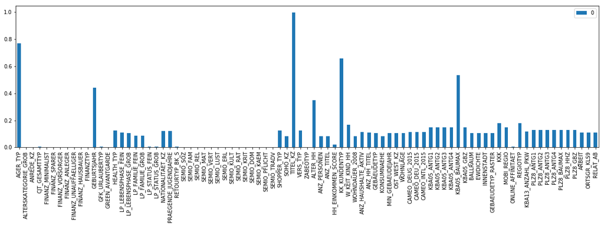

```python
# Investigate patterns in the amount of missing data in each column.
nan_percent_per_col.T.plot(kind="bar", figsize=(20,5))
```

[output not shown]

[output not shown]

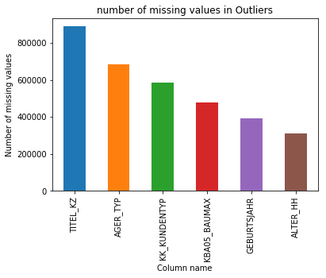

```python
outliers = azdias.columns[azdias.isnull().sum() > 200000]
print(outliers)
azdias[outliers].isnull().sum().sort_values(ascending=False).plot(kind="bar")
plt.title("number of missing values in Outliers")
plt.xlabel("Column name")
plt.ylabel("Number of missing values")
```

```python
# Remove the outlier columns from the dataset. (You'll perform other data
# engineering tasks such as re-encoding and imputation later.)
azdias= azdias.drop(columns=outliers)
azdias.shape
```

```
(891221, 79)
```

```python
#missing vals in other columns
print(azdias.isnull().sum()[azdias.isnull().sum() <= 200000].sort_values())
```

```
ZABEOTYP                      0
SEMIO_REL                     0
SEMIO_MAT                     0
SEMIO_VERT                    0
SEMIO_LUST                    0
SEMIO_ERL                     0
SEMIO_KULT                    0
SEMIO_RAT                     0
SEMIO_KRIT                    0
SEMIO_DOM                     0
SEMIO_KAEM                    0
GREEN_AVANTGARDE              0
SEMIO_PFLICHT                 0
FINANZTYP                     0
FINANZ_HAUSBAUER              0
FINANZ_UNAUFFAELLIGER         0
FINANZ_ANLEGER                0
FINANZ_VORSORGER              0
FINANZ_SPARER                 0
FINANZ_MINIMALIST             0
SEMIO_TRADV                   0
ANREDE_KZ                     0
SEMIO_SOZ                     0
SEMIO_FAM                     0
ALTERSKATEGORIE_GROB       2881
LP_STATUS_GROB             4854
LP_STATUS_FEIN             4854
ONLINE_AFFINITAET          4854
RETOURTYP_BK_S             4854
GFK_URLAUBERTYP            4854
                          ...
ORTSGR_KLS9               97274
ARBEIT                    97375
RELAT_AB                  97375
LP_LEBENSPHASE_FEIN       97632
CAMEO_DEUG_2015           99352
CAMEO_DEU_2015            99352
CAMEO_INTL_2015           99352
ANZ_HAUSHALTE_AKTIV       99611
KBA13_ANZAHL_PKW         105800
PRAEGENDE_JUGENDJAHRE    108164
NATIONALITAET_KZ         108315
VERS_TYP                 111196
SHOPPER_TYP              111196
HEALTH_TYP               111196
PLZ8_GBZ                 116515
PLZ8_HHZ                 116515
PLZ8_BAUMAX              116515
PLZ8_ANTG4               116515
PLZ8_ANTG3               116515
PLZ8_ANTG1               116515
PLZ8_ANTG2               116515
KBA05_GBZ                133324
KBA05_ANTG1              133324
KBA05_ANTG2              133324
KBA05_ANTG3              133324
KBA05_ANTG4              133324
MOBI_REGIO               133324
W_KEIT_KIND_HH           147988
REGIOTYP                 158064
KKK                      158064
Length: 79, dtype: int64
```

#### Discussion 1.1.2: Assess Missing Data in Each Column

For the majority of the columns, missing values constituted less than 20% of their values. There were only 6 columns with a proportion of missing values that exceeded 20%. The 6 I removed columns had the most missing values. Those columns might not be that useful for clustering.

#### Step 1.1.3: Assess Missing Data in Each Row

Now, you'll perform a similar assessment for the rows of the dataset. How much data is missing in each row? As with the columns, you should see some groups of points that have a very different numbers of missing values. Divide the data into two subsets: one for data points that are above some threshold for missing values, and a second subset for points below that threshold.

In order to know what to do with the outlier rows, we should see if the distribution of data values on columns that are not missing data (or are missing very little data) are similar or different between the two groups. Select at least five of these columns and compare the distribution of values.

- You can use seaborn's [`countplot()`](https://seaborn.pydata.org/generated/seaborn.countplot.html) function to create a bar chart of code frequencies and matplotlib's [`subplot()`](https://matplotlib.org/api/_as_gen/matplotlib.pyplot.subplot.html) function to put bar charts for the two subplots side by side.
- To reduce repeated code, you might want to write a function that can perform this comparison, taking as one of its arguments a column to be compared.

Depending on what you observe in your comparison, this will have implications on how you approach your conclusions later in the analysis. If the distributions of non-missing features look similar between the data with many missing values and the data with few or no missing values, then we could argue that simply dropping those points from the analysis won't present a major issue. On the other hand, if the data with many missing values looks very different from the data with few or no missing values, then we should make a note on those data as special. We'll revisit these data later on. **Either way, you should continue your analysis for now using just the subset of the data with few or no missing values.**

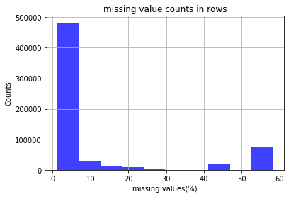

```python
# How much data is missing in each row of the dataset?
missing_val_row = azdias_org.isnull().sum(axis=1)
missing_val_row = missing_val_row[missing_val_row > 0]/(len(azdias.columns)) * 100
plt.hist(missing_val_row, bins=10, facecolor='b', alpha=0.75)
plt.xlabel('missing values(%)')
plt.ylabel('Counts')
plt.title('missing value counts in rows')
plt.grid(True)
plt.show()
```

```python
# Write code to divide the data into two subsets based on the number of missing
# values in each row.
missing_data_lt2 = azdias[azdias.isnull().sum(axis=1) < 22].reset_index(drop=True)
missing_data_ge2 = azdias[azdias.isnull().sum(axis=1) >= 22].reset_index(drop=True)
```

```python
print(missing_data_lt2.shape)
```

```
(797576, 79)
```

```python
print(missing_data_ge2.shape)
missing_data_ge2.head()
```

```
(93645, 79)
```

|  | ALTERSKATEGORIE_GROB | ANREDE_KZ | CJT_GESAMTTYP | FINANZ_MINIMALIST | FINANZ_SPARER | FINANZ_VORSORGER | FINANZ_ANLEGER | FINANZ_UNAUFFAELLIGER | FINANZ_HAUSBAUER | FINANZTYP | ... | PLZ8_ANTG1 | PLZ8_ANTG2 | PLZ8_ANTG3 | PLZ8_ANTG4 | PLZ8_BAUMAX | PLZ8_HHZ | PLZ8_GBZ | ARBEIT | ORTSGR_KLS9 | RELAT_AB |
| --- | --- | --- | --- | --- | --- | --- | --- | --- | --- | --- | --- | --- | --- | --- | --- | --- | --- | --- | --- | --- | --- |
| 0 | 2.0 | 1 | 2.0 | 3 | 4 | 3 | 5 | 5 | 3 | 4 | ... | NaN | NaN | NaN | NaN | NaN | NaN | NaN | NaN | NaN | NaN |
| 1 | 2.0 | 1 | 6.0 | 3 | 4 | 3 | 5 | 5 | 3 | 4 | ... | NaN | NaN | NaN | NaN | NaN | NaN | NaN | NaN | NaN | NaN |
| 2 | 3.0 | 1 | 6.0 | 3 | 4 | 3 | 5 | 5 | 3 | 4 | ... | NaN | NaN | NaN | NaN | NaN | NaN | NaN | NaN | NaN | NaN |
| 3 | 2.0 | 1 | 6.0 | 3 | 4 | 3 | 5 | 5 | 3 | 4 | ... | NaN | NaN | NaN | NaN | NaN | NaN | NaN | NaN | NaN | NaN |
| 4 | 3.0 | 2 | 6.0 | 3 | 4 | 3 | 5 | 5 | 3 | 4 | ... | NaN | NaN | NaN | NaN | NaN | NaN | NaN | NaN | NaN | NaN |

5 rows × 79 columns

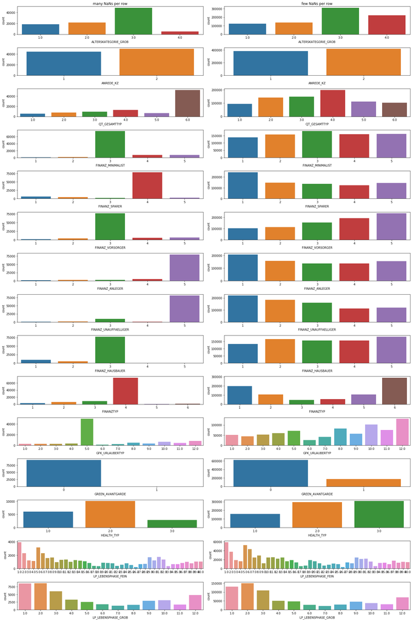

```python
# Compare the distribution of values for at least five columns where there are
# no or few missing values, between the two subsets.
row = 15
col = 2
fig, ax= plt.subplots(nrows = row,ncols = col,figsize=(20,30))

for i in range(row):
    sns.countplot(x=missing_data_ge2.columns[i],data=missing_data_ge2, ax=ax[i][0])
    sns.countplot(x=missing_data_lt2.columns[i],data=missing_data_lt2, ax=ax[i][1])

ax[0][0].set_title('many NaNs per row')
ax[0][1].set_title('few NaNs per row')
fig.tight_layout()
fig.show()
```

#### Discussion 1.1.3: Assess Missing Data in Each Row

It seems that the average of rows are missing around 5 to 6% of data. I decided on choosing the threshold to be 22 based on the result from the histogram of counts of missing values. What we can understand from the results is that the populations are similar when it comes to age, gender, life stage but different when it comes to finacial spending practices and vacation habits.

### Step 1.2: Select and Re-Encode Features

Checking for missing data isn't the only way in which you can prepare a dataset for analysis. Since the unsupervised learning techniques to be used will only work on data that is encoded numerically, you need to make a few encoding changes or additional assumptions to be able to make progress. In addition, while almost all of the values in the dataset are encoded using numbers, not all of them represent numeric values. Check the third column of the feature summary (`feat_info`) for a summary of types of measurement.

- For numeric and interval data, these features can be kept without changes.
- Most of the variables in the dataset are ordinal in nature. While ordinal values may technically be non-linear in spacing, make the simplifying assumption that the ordinal variables can be treated as being interval in nature (that is, kept without any changes).
- Special handling may be necessary for the remaining two variable types: categorical, and 'mixed'.

In the first two parts of this sub-step, you will perform an investigation of the categorical and mixed-type features and make a decision on each of them, whether you will keep, drop, or re-encode each. Then, in the last part, you will create a new data frame with only the selected and engineered columns.

Data wrangling is often the trickiest part of the data analysis process, and there's a lot of it to be done here. But stick with it: once you're done with this step, you'll be ready to get to the machine learning parts of the project!

```python
# How many features are there of each data type?
feature_per_dtype = {}
for x in missing_data_lt2.columns:
    dtype = feat_info.loc[x].type
    if dtype not in feature_per_dtype:
        feature_per_dtype[dtype] = 1
    else :
        feature_per_dtype[dtype] += 1

print(feature_per_dtype)
```

```
{'ordinal': 49, 'categorical': 18, 'mixed': 6, 'numeric': 6}
```

#### Step 1.2.1: Re-Encode Categorical Features

For categorical data, you would ordinarily need to encode the levels as dummy variables. Depending on the number of categories, perform one of the following:

- For binary (two-level) categoricals that take numeric values, you can keep them without needing to do anything.
- There is one binary variable that takes on non-numeric values. For this one, you need to re-encode the values as numbers or create a dummy variable.
- For multi-level categoricals (three or more values), you can choose to encode the values using multiple dummy variables (e.g. via [OneHotEncoder](http://scikit-learn.org/stable/modules/generated/sklearn.preprocessing.OneHotEncoder.html)), or (to keep things straightforward) just drop them from the analysis. As always, document your choices in the Discussion section.

```python
def create_binary_multi_level_feat_list(data,feat_info):
    bin_list = []
    multi_level_list = []
    available_feat = []
    cat_feat = feat_info[feat_info['type'] == 'categorical']['attribute'].tolist()
    for f in cat_feat:
        if f in data:
            available_feat.append(f)
    cat_variable=data[available_feat]
    #print(cat_variable.info())
    for i in available_feat:
        if len(cat_variable[i].value_counts()) == 2 and (set(cat_variable[i]) & set([0,1])== set([0,1]) or
                                                         set(cat_variable[i]) & set([0.0,1.0]) == set([0.0,1.0])):
            bin_list.append(i)
        else :
            multi_level_list.append(i)

    return bin_list, multi_level_list
```

```python
bin_list,multi_level_list=create_binary_multi_level_feat_list(missing_data_lt2,feat_info_org)
pprint('Binary: {}'.format(bin_list))
pprint('multi-level: {}'.format(multi_level_list))
missing_data_lt2[['GREEN_AVANTGARDE','SOHO_KZ','ANREDE_KZ']].T
```

```
"Binary: ['GREEN_AVANTGARDE', 'SOHO_KZ']"
("multi-level: ['ANREDE_KZ', 'CJT_GESAMTTYP', 'FINANZTYP', 'GFK_URLAUBERTYP', "
 "'LP_FAMILIE_FEIN', 'LP_FAMILIE_GROB', 'LP_STATUS_FEIN', 'LP_STATUS_GROB', "
 "'NATIONALITAET_KZ', 'SHOPPER_TYP', 'VERS_TYP', 'ZABEOTYP', 'GEBAEUDETYP', "
 "'OST_WEST_KZ', 'CAMEO_DEUG_2015', 'CAMEO_DEU_2015']")
```

|  | 0 | 1 | 2 | 3 | 4 | 5 | 6 | 7 | 8 | 9 | ... | 797566 | 797567 | 797568 | 797569 | 797570 | 797571 | 797572 | 797573 | 797574 | 797575 |
| --- | --- | --- | --- | --- | --- | --- | --- | --- | --- | --- | --- | --- | --- | --- | --- | --- | --- | --- | --- | --- | --- |
| GREEN_AVANTGARDE | 0.0 | 1.0 | 0.0 | 0.0 | 0.0 | 0.0 | 0.0 | 1.0 | 1.0 | 0.0 | ... | 0.0 | 0.0 | 1.0 | 0.0 | 0.0 | 0.0 | 0.0 | 0.0 | 0.0 | 0.0 |
| SOHO_KZ | 1.0 | 0.0 | 0.0 | 0.0 | 0.0 | 0.0 | 0.0 | 0.0 | 0.0 | 0.0 | ... | 0.0 | 0.0 | 0.0 | 0.0 | 0.0 | 0.0 | 0.0 | 0.0 | 0.0 | 0.0 |
| ANREDE_KZ | 2.0 | 2.0 | 2.0 | 1.0 | 2.0 | 2.0 | 1.0 | 1.0 | 2.0 | 2.0 | ... | 1.0 | 1.0 | 2.0 | 2.0 | 2.0 | 2.0 | 1.0 | 2.0 | 1.0 | 1.0 |

3 rows × 797576 columns

```python
# Re-encode categorical variable(s) to be kept in the analysis.
dummies_df = pd.get_dummies(missing_data_lt2,columns=bin_list, drop_first= True)

for c in multi_level_list:
    dummies_df.drop(c,axis=1,inplace = True)
print(dummies_df.columns.tolist())
```

```
['ALTERSKATEGORIE_GROB', 'FINANZ_MINIMALIST', 'FINANZ_SPARER', 'FINANZ_VORSORGER', 'FINANZ_ANLEGER', 'FINANZ_UNAUFFAELLIGER', 'FINANZ_HAUSBAUER', 'HEALTH_TYP', 'LP_LEBENSPHASE_FEIN', 'LP_LEBENSPHASE_GROB', 'PRAEGENDE_JUGENDJAHRE', 'RETOURTYP_BK_S', 'SEMIO_SOZ', 'SEMIO_FAM', 'SEMIO_REL', 'SEMIO_MAT',…
```

#### Discussion 1.2.1: Re-Encode Categorical Features

1. I checked the variability in the dataset to visualize the categories and indicate categorical results then split the categorical columns between binary , and multi-level based on AZDIAS_Feature_Summary
2. I refered back to Data_Dictionary.md and the visualized categories above to check the values and decided to drop all the multi-level features. For that, i used get_dummies for encoding with dropping the first accurance.

#### Step 1.2.2: Engineer Mixed-Type Features

There are a handful of features that are marked as "mixed" in the feature summary that require special treatment in order to be included in the analysis. There are two in particular that deserve attention; the handling of the rest are up to your own choices:

- "PRAEGENDE_JUGENDJAHRE" combines information on three dimensions: generation by decade, movement (mainstream vs. avantgarde), and nation (east vs. west). While there aren't enough levels to disentangle east from west, you should create two new variables to capture the other two dimensions: an interval-type variable for decade, and a binary variable for movement.
- "CAMEO_INTL_2015" combines information on two axes: wealth and life stage. Break up the two-digit codes by their 'tens'-place and 'ones'-place digits into two new ordinal variables (which, for the purposes of this project, is equivalent to just treating them as their raw numeric values).
- If you decide to keep or engineer new features around the other mixed-type features, make sure you note your steps in the Discussion section.

Be sure to check `Data_Dictionary.md` for the details needed to finish these tasks.

```python
# Investigate "PRAEGENDE_JUGENDJAHRE" and engineer two new variables.
fv_dic = {
  -1:{'period': np.nan, 'direction': np.nan},
    0:{'period': np.nan, 'direction': np.nan},
    1: {'period': 40, 'direction': 'EW'},
    2: {'period': 40, 'direction': 'EW'},
    3: {'period': 50, 'direction': 'EW'},
    4: {'period': 50, 'direction': 'EW'},
    5: {'period': 60, 'direction': 'EW'},
    6: {'period': 60, 'direction': 'W'},
    7: {'period': 60, 'direction': 'E'},
    8: {'period': 70, 'direction': 'EW'},
    9: {'period': 70, 'direction': 'EW'},
    10: {'period': 80, 'direction': 'W'},
    11: {'period': 80, 'direction': 'W'},
    12: {'period': 80, 'direction': 'E'},
    13: {'period': 80, 'direction': 'E'},
    14: {'period': 90, 'direction': 'EW'},
    15: {'period': 90, 'direction': 'EW'}
}
```

```python
dummies_df['PRAEGENDE_JUGENDJAHRE_PERIOD']= 0
dummies_df['PRAEGENDE_JUGENDJAHRE_DIRECTION'] = 'x'
```

```python
for k,v in fv_dic.items():
    idx=dummies_df[dummies_df['PRAEGENDE_JUGENDJAHRE'] == k].index
    dummies_df.loc[idx,'PRAEGENDE_JUGENDJAHRE_PERIOD']= v['period']
    dummies_df.loc[idx,'PRAEGENDE_JUGENDJAHRE_DIRECTION']= v['direction']
```

```python
print('missing vals in PRAEGENDE_JUGENDJAHRE_PERIOD: ', dummies_df[dummies_df['PRAEGENDE_JUGENDJAHRE_PERIOD'] == 0].shape[0])
print('missing vals in PRAEGENDE_JUGENDJAHRE_DIRECTION: ', dummies_df[dummies_df['PRAEGENDE_JUGENDJAHRE_DIRECTION'] == 'x'].shape[0])
```

```
missing vals in PRAEGENDE_JUGENDJAHRE_PERIOD:  28530
missing vals in PRAEGENDE_JUGENDJAHRE_DIRECTION:  28530
```

```python
dummies_df.drop(['PRAEGENDE_JUGENDJAHRE'], axis=1, inplace=True)
dummies_df = pd.get_dummies( dummies_df, columns = ['PRAEGENDE_JUGENDJAHRE_DIRECTION'] ,drop_first=True)
```

```python
dummies_df['CAMEO_INTL_2015'].value_counts(dropna=False)
```

```
51     133679
41      92322
24      91115
14      62859
43      56663
54      45384
25      39612
22      33140
23      26680
13      26320
45      26130
55      23948
52      20540
31      18992
34      18521
15      16968
44      14818
12      13235
35      10352
32      10349
33       9930
NaN      6019
Name: CAMEO_INTL_2015, dtype: int64
```

```python
def get_l_s(num):
    if num == '-1' or num =='XX' or math.isnan(float(num)):
        return np.nan
    return int(num) % 10
```

```python
def get_wealth(num):
    if num == '-1' or num =='XX' or math.isnan(float(num)):
        return np.nan
    return (int(num) //10) % 10
```

```python
# Investigate "CAMEO_INTL_2015" and engineer two new variables.
dummies_df['CAMEO_INTL_2015_WEALTH'] = dummies_df['CAMEO_INTL_2015'].apply(get_wealth)
dummies_df['CAMEO_INTL_2015_LIFE_STAGE'] = dummies_df['CAMEO_INTL_2015'].apply(get_l_s)
print(dummies_df[['CAMEO_INTL_2015', 'CAMEO_INTL_2015_WEALTH', 'CAMEO_INTL_2015_LIFE_STAGE']].head(10).T)
dummies_df.drop('CAMEO_INTL_2015', axis=1, inplace=True)
```

```
                             0   1   2   3   4   5   6   7   8   9
CAMEO_INTL_2015             51  24  12  43  54  22  14  13  15  51
CAMEO_INTL_2015_WEALTH       5   2   1   4   5   2   1   1   1   5
CAMEO_INTL_2015_LIFE_STAGE   1   4   2   3   4   2   4   3   5   1
```

```python
mix_feat_df = feat_info.loc[missing_data_lt2.columns][['columns','type']].query('type=="mixed"')
cols = set(mix_feat_df['columns'].tolist())
cols = cols - set(['CAMEO_INTL_2015', 'PRAEGENDE_JUGENDJAHRE'])

pprint(f'columns that will be dropped: {cols}')
dummies_df.drop(cols,axis=1,inplace=True)
cols in set(dummies_df.columns)
dummies_df.shape
```

```
("columns that will be dropped: {'WOHNLAGE', 'PLZ8_BAUMAX', "
 "'LP_LEBENSPHASE_FEIN', 'LP_LEBENSPHASE_GROB'}")
```

```
(797576, 63)
```

#### Discussion 1.2.2: Engineer Mixed-Type Features

Dropped all mixed featured other than the two Features that have been engineered in the previous steps.

For **PRAEGENDE_JUGENDJAHRE**, I created a dictionary for the values to be inserted in the generated features, initialzed the new features in the dataframe, looping over the dictionary elements and appending the proper values in each row that matches the values based on the rows' index.

For **CAMEO_INTL_2015**, I created 2 functions to get features values from the original feature and apply them to that column to fill the new features

For the **Dropped Features**, i extracted the mixed features from feat_info, get the columns and convert them to sets, then substract the 2 columns that has been already processes in the previous steps and then drop the remaining columns.

#### Step 1.2.3: Complete Feature Selection

In order to finish this step up, you need to make sure that your data frame now only has the columns that you want to keep. To summarize, the dataframe should consist of the following:

- All numeric, interval, and ordinal type columns from the original dataset.
- Binary categorical features (all numerically-encoded).
- Engineered features from other multi-level categorical features and mixed features.

Make sure that for any new columns that you have engineered, that you've excluded the original columns from the final dataset. Otherwise, their values will interfere with the analysis later on the project. For example, you should not keep "PRAEGENDE_JUGENDJAHRE", since its values won't be useful for the algorithm: only the values derived from it in the engineered features you created should be retained. As a reminder, your data should only be from **the subset with few or no missing values**.

```python
# If there are other re-engineering tasks you need to perform, make sure you
# take care of them here. (Dealing with missing data will come in step 2.1.)
feat =feat_info_org[['attribute','type']]
cols =feat['attribute']

remaining_cols_dict = {}
for col in cols.values:
    if col in dummies_df or dummies_df.columns.str.startswith(col).any():
        df_cols =dummies_df.filter(regex=f'{col}.*').columns.values
        remaining_cols_dict[col] ={
            'category':feat[feat['attribute']== col].iloc[0][1],
            'columns':df_cols
        }
```

```python
pprint(f'number of the features {dummies_df.shape[1]}')
pprint(remaining_cols_dict.keys())
```

```
'number of the features 63'
dict_keys(['ALTERSKATEGORIE_GROB', 'FINANZ_MINIMALIST', 'FINANZ_SPARER', 'FINANZ_VORSORGER', 'FINANZ_ANLEGER', 'FINANZ_UNAUFFAELLIGER', 'FINANZ_HAUSBAUER', 'GREEN_AVANTGARDE', 'HEALTH_TYP', 'PRAEGENDE_JUGENDJAHRE', 'RETOURTYP_BK_S', 'SEMIO_SOZ', 'SEMIO_FAM', 'SEMIO_REL', 'SEMIO_MAT', 'SEMIO_VERT', '…
```

```python
# Do whatever you need to in order to ensure that the dataframe only contains
# the columns that should be passed to the algorithm functions.
cols = ['AGER_TYP','GEBURTSJAHR','TITEL_KZ','KK_KUNDENTYP','KBA05_BAUMAX','ALTER_HH']
for c in cols :
    if c in remaining_cols_dict.keys() and remaining_cols_dict[c]['category'] =='categorical':
        dummies_df.drop(remaining_cols_dict[c]['columns'],axis = 1, inplace= True)
        print(f'dropping: {remaining_cols_dict[c]["columns"]}')

dummies_df.shape
```

```
(797576, 63)
```

### Step 1.3: Create a Cleaning Function

Even though you've finished cleaning up the general population demographics data, it's important to look ahead to the future and realize that you'll need to perform the same cleaning steps on the customer demographics data. In this substep, complete the function below to execute the main feature selection, encoding, and re-engineering steps you performed above. Then, when it comes to looking at the customer data in Step 3, you can just run this function on that DataFrame to get the trimmed dataset in a single step.

```python
def clean_data(df):
    """
    Perform feature trimming, re-encoding, and engineering for demographics
    data

    INPUT: Demographics DataFrame
    OUTPUT: Trimmed and cleaned demographics DataFrame
    """
    feat = pd.read_csv('AZDIAS_Feature_Summary.csv', delimiter=';')
    missing_feat_dict = get_missing_feats_dict_from_feats_info(feat)

    # Put in code here to execute all main cleaning steps:
    # convert missing value codes into NaNs, ...
    for k,v in missing_feat_dict.items():
        df[k].replace(v,inplace=True)

    # remove selected columns and rows, ...
    columns_to_drop = ['AGER_TYP', 'GEBURTSJAHR', 'TITEL_KZ', 'ALTER_HH', 'KK_KUNDENTYP','KBA05_BAUMAX']
    df.drop(columns_to_drop, axis=1, inplace=True)
    df = df[df.isnull().sum(axis=1) < 22].reset_index(drop=True)
    binary_feat_list, multi_level_list =  create_binary_multi_level_feat_list(df, feat)
    df= pd.get_dummies( df, columns = binary_feat_list ,drop_first=True)
    for col in multi_level_list:
        df.drop(col, axis=1, inplace=True)
    df['CAMEO_INTL_2015_WEALTH'] = df['CAMEO_INTL_2015'].apply(get_wealth)
    df['CAMEO_INTL_2015_LIFE_STAGE'] = df['CAMEO_INTL_2015'].apply(get_l_s)
    df.drop('CAMEO_INTL_2015', axis=1, inplace=True)
    f_var_dict = {
        -1:{'period': np.nan, 'direction': np.nan},
        0:{'period': np.nan, 'direction': np.nan},
        1: {'period': 40, 'direction': 'EW'},
        2: {'period': 40, 'direction': 'EW'},
        3: {'period': 50, 'direction': 'EW'},
        4: {'period': 50, 'direction': 'EW'},
        5: {'period': 60, 'direction': 'EW'},
        6: {'period': 60, 'direction': 'W'},
        7: {'period': 60, 'direction': 'E'},
        8: {'period': 70, 'direction': 'EW'},
        9: {'period': 70, 'direction': 'EW'},
        10: {'period': 80, 'direction': 'W'},
        11: {'period': 80, 'direction': 'W'},
        12: {'period': 80, 'direction': 'E'},
        13: {'period': 80, 'direction': 'E'},
        14: {'period': 90, 'direction': 'EW'},
        15: {'period': 90, 'direction': 'EW'}
    }
    df['PRAEGENDE_JUGENDJAHRE_PERIOD']= 0
    df['PRAEGENDE_JUGENDJAHRE_DIRECTION'] = 'x'
    for k, v in f_var_dict.items():
        row_indexes = df[df['PRAEGENDE_JUGENDJAHRE'] == k].index
        df.loc[row_indexes,'PRAEGENDE_JUGENDJAHRE_PERIOD']= v['period']
        df.loc[row_indexes,'PRAEGENDE_JUGENDJAHRE_DIRECTION']= v['direction']
    print(f'missing values for [PRAEGENDE_JUGENDJAHRE_PERIOD]: ', df[df['PRAEGENDE_JUGENDJAHRE_PERIOD'] == 0].shape[0])
    print('missing values for [PRAEGENDE_JUGENDJAHRE_DIRECTION]: ', df[df['PRAEGENDE_JUGENDJAHRE_DIRECTION'] == 'x'].shape[0])
    df.drop(['PRAEGENDE_JUGENDJAHRE'], axis=1, inplace=True)
    df = pd.get_dummies( df, columns = ['PRAEGENDE_JUGENDJAHRE_DIRECTION'] ,drop_first=True)
    mixed_features_df = feat.query('type == "mixed"')[['attribute','type']]
    columns = set(mixed_features_df['attribute'].tolist())
    columns = columns  - set(columns_to_drop) - set(['PRAEGENDE_JUGENDJAHRE', 'CAMEO_INTL_2015'])
    df.drop(columns, axis=1, inplace=True)
    columns in set(df.columns)
    features = feat[['attribute','type']]
    columns = features['attribute'].tolist()
    dict_remaining_cols = {}
    for col in columns:
        if col in df or df.columns.str.startswith(col).any():
            df_columns = df.filter(regex=f'{col}.*').columns.tolist()
            dict_remaining_cols[col] = {
                'category' :features[features['attribute'] == col ].iloc[0][1],
                'columns': df_columns
            }

    for c in columns_to_drop:
        if c in dict_remaining_cols.keys() and dict_of_remaining_cols[c]['category']== 'categorical':
            df.drop(dict_of_remaining_cols[c]['columns'], axis=1, inplace=True)


    if 'GEBAEUDETYP_5.0' in df.columns:
        df.drop(['GEBAEUDETYP_5.0'], axis=1, inplace=True)

    # Return the cleaned dataframe.
    return df
```

```python
clean_df = clean_data(pd.read_csv('Udacity_AZDIAS_Subset.csv', delimiter=';'))
clean_df.shape
```

```
missing values for [PRAEGENDE_JUGENDJAHRE_PERIOD]:  28530
missing values for [PRAEGENDE_JUGENDJAHRE_DIRECTION]:  28530
```

```
(797576, 63)
```

## Step 2: Feature Transformation

### Step 2.1: Apply Feature Scaling

Before we apply dimensionality reduction techniques to the data, we need to perform feature scaling so that the principal component vectors are not influenced by the natural differences in scale for features. Starting from this part of the project, you'll want to keep an eye on the [API reference page for sklearn](http://scikit-learn.org/stable/modules/classes.html) to help you navigate to all of the classes and functions that you'll need. In this substep, you'll need to check the following:

- sklearn requires that data not have missing values in order for its estimators to work properly. So, before applying the scaler to your data, make sure that you've cleaned the DataFrame of the remaining missing values. This can be as simple as just removing all data points with missing data, or applying an [Imputer](http://scikit-learn.org/stable/modules/generated/sklearn.preprocessing.Imputer.html) to replace all missing values. You might also try a more complicated procedure where you temporarily remove missing values in order to compute the scaling parameters before re-introducing those missing values and applying imputation. Think about how much missing data you have and what possible effects each approach might have on your analysis, and justify your decision in the discussion section below.
- For the actual scaling function, a [StandardScaler](http://scikit-learn.org/stable/modules/generated/sklearn.preprocessing.StandardScaler.html) instance is suggested, scaling each feature to mean 0 and standard deviation 1.
- For these classes, you can make use of the `.fit_transform()` method to both fit a procedure to the data as well as apply the transformation to the data at the same time. Don't forget to keep the fit sklearn objects handy, since you'll be applying them to the customer demographics data towards the end of the project.

```python
# If you've not yet cleaned the dataset of all NaN values, then investigate and
# do that now.
fill_nan = Imputer(missing_values=np.nan, strategy='mean', axis=1)
imputed_df = pd.DataFrame(fill_nan.transform(clean_df))
imputed_df.columns=clean_df.columns
imputed_df.index=clean_df.index
imputed_df.head()
```

|  | ALTERSKATEGORIE_GROB | FINANZ_MINIMALIST | FINANZ_SPARER | FINANZ_VORSORGER | FINANZ_ANLEGER | FINANZ_UNAUFFAELLIGER | FINANZ_HAUSBAUER | HEALTH_TYP | RETOURTYP_BK_S | SEMIO_SOZ | ... | ORTSGR_KLS9 | RELAT_AB | GREEN_AVANTGARDE_1 | SOHO_KZ_1.0 | CAMEO_INTL_2015_WEALTH | CAMEO_INTL_2015_LIFE_STAGE | PRAEGENDE_JUGENDJAHRE_PERIOD | PRAEGENDE_JUGENDJAHRE_DIRECTION_EW | PRAEGENDE_JUGENDJAHRE_DIRECTION_W | PRAEGENDE_JUGENDJAHRE_DIRECTION_x |
| --- | --- | --- | --- | --- | --- | --- | --- | --- | --- | --- | --- | --- | --- | --- | --- | --- | --- | --- | --- | --- | --- |
| 0 | 1.0 | 1.0 | 5.0 | 2.0 | 5.0 | 4.0 | 5.0 | 3.0 | 1.0 | 5.0 | ... | 5.0 | 4.0 | 0.0 | 1.0 | 5.0 | 1.0 | 90.0 | 1.0 | 0.0 | 0.0 |
| 1 | 3.0 | 1.0 | 4.0 | 1.0 | 2.0 | 3.0 | 5.0 | 3.0 | 3.0 | 4.0 | ... | 5.0 | 2.0 | 1.0 | 0.0 | 2.0 | 4.0 | 90.0 | 1.0 | 0.0 | 0.0 |
| 2 | 4.0 | 4.0 | 2.0 | 5.0 | 2.0 | 1.0 | 2.0 | 2.0 | 2.0 | 5.0 | ... | 3.0 | 3.0 | 0.0 | 0.0 | 1.0 | 2.0 | 70.0 | 1.0 | 0.0 | 0.0 |
| 3 | 3.0 | 4.0 | 3.0 | 4.0 | 1.0 | 3.0 | 2.0 | 3.0 | 5.0 | 6.0 | ... | 6.0 | 5.0 | 0.0 | 0.0 | 4.0 | 3.0 | 70.0 | 1.0 | 0.0 | 0.0 |
| 4 | 1.0 | 3.0 | 1.0 | 5.0 | 2.0 | 2.0 | 5.0 | 3.0 | 3.0 | 2.0 | ... | 3.0 | 3.0 | 0.0 | 0.0 | 5.0 | 4.0 | 50.0 | 1.0 | 0.0 | 0.0 |

5 rows × 63 columns

```python
# Apply feature scaling to the general population demographics data.
scaler = StandardScaler()
imputed_df[imputed_df.columns] = scaler.fit_transform(imputed_df[imputed_df.columns].as_matrix())
imputed_df.head()
```

|  | ALTERSKATEGORIE_GROB | FINANZ_MINIMALIST | FINANZ_SPARER | FINANZ_VORSORGER | FINANZ_ANLEGER | FINANZ_UNAUFFAELLIGER | FINANZ_HAUSBAUER | HEALTH_TYP | RETOURTYP_BK_S | SEMIO_SOZ | ... | ORTSGR_KLS9 | RELAT_AB | GREEN_AVANTGARDE_1 | SOHO_KZ_1.0 | CAMEO_INTL_2015_WEALTH | CAMEO_INTL_2015_LIFE_STAGE | PRAEGENDE_JUGENDJAHRE_PERIOD | PRAEGENDE_JUGENDJAHRE_DIRECTION_EW | PRAEGENDE_JUGENDJAHRE_DIRECTION_W | PRAEGENDE_JUGENDJAHRE_DIRECTION_x |
| --- | --- | --- | --- | --- | --- | --- | --- | --- | --- | --- | --- | --- | --- | --- | --- | --- | --- | --- | --- | --- | --- |
| 0 | -0.680361 | -1.494593 | 1.538151 | -1.040714 | 1.466365 | 0.959456 | 1.338931 | -0.130415 | -0.735673 | 0.442810 | ... | -0.134705 | 0.202588 | -0.530523 | 10.852432 | 0.350375 | -0.540734 | 0.977172 | 0.597652 | -0.475679 | -0.192608 |
| 1 | 0.016363 | -1.494593 | 0.864780 | -1.766947 | -0.570816 | 0.244778 | 1.338931 | -0.130415 | -0.190378 | -0.072392 | ... | -0.134705 | -0.377227 | 1.884933 | -0.092145 | -0.393726 | 0.196329 | 0.977172 | 0.597652 | -0.475679 | -0.192608 |
| 2 | 0.364726 | 0.683161 | -0.481962 | 1.137984 | -0.570816 | -1.184577 | -0.791880 | -0.237760 | -0.463026 | 0.442810 | ... | -0.665473 | -0.087320 | -0.530523 | -0.092145 | -0.641760 | -0.295046 | -0.035269 | 0.597652 | -0.475679 | -0.192608 |
| 3 | 0.016363 | 0.683161 | 0.191409 | 0.411752 | -1.249877 | 0.244778 | -0.791880 | -0.130415 | 0.354916 | 0.958013 | ... | 0.130679 | 0.492496 | -0.530523 | -0.092145 | 0.102341 | -0.049358 | -0.035269 | 0.597652 | -0.475679 | -0.192608 |
| 4 | -0.680361 | -0.042757 | -1.155333 | 1.137984 | -0.570816 | -0.469899 | 1.338931 | -0.130415 | -0.190378 | -1.102797 | ... | -0.665473 | -0.087320 | -0.530523 | -0.092145 | 0.350375 | 0.196329 | -1.047710 | 0.597652 | -0.475679 | -0.192608 |

5 rows × 63 columns

### Discussion 2.1: Apply Feature Scaling

I replaced NaN values with the mean and decided on scaling all features

### Step 2.2: Perform Dimensionality Reduction

On your scaled data, you are now ready to apply dimensionality reduction techniques.

- Use sklearn's [PCA](http://scikit-learn.org/stable/modules/generated/sklearn.decomposition.PCA.html) class to apply principal component analysis on the data, thus finding the vectors of maximal variance in the data. To start, you should not set any parameters (so all components are computed) or set a number of components that is at least half the number of features (so there's enough features to see the general trend in variability).
- Check out the ratio of variance explained by each principal component as well as the cumulative variance explained. Try plotting the cumulative or sequential values using matplotlib's [`plot()`](https://matplotlib.org/api/_as_gen/matplotlib.pyplot.plot.html) function. Based on what you find, select a value for the number of transformed features you'll retain for the clustering part of the project.
- Once you've made a choice for the number of components to keep, make sure you re-fit a PCA instance to perform the decided-on transformation.

```python
# Apply PCA to the data.

def do_pca(n_components, data):
    pca = PCA(n_components)
    X_pca = pca.fit_transform(data)
    return pca, X_pca

def scree_plot(pca):
    fig, ax = plt.subplots(figsize=(25,7))
    cumsum = np.cumsum(pca.explained_variance_ratio_)
    plt.plot(np.apply_along_axis(lambda x: x*100, 0, cumsum))
    ax.grid()
    plt.xticks(range(0, pca.explained_variance_.shape[0]+10, 10))
    plt.yticks(range(0, 100, 10))
    plt.xlabel('number of components')
    plt.ylabel('cumulative explained variance')


def explain_variance(pca):
    fig, ax = plt.subplots(figsize=(25,7))
    ax.grid()
    cumsum = np.cumsum(pca.explained_variance_ratio_)
    plt.plot(pca.explained_variance_ratio_, label='variance')
    plt.xticks(range(0, pca.explained_variance_.shape[0]+10, 10))
    plt.xlabel('number of components')
    plt.ylabel('cumulative explained variance')


def pca_results(full_dataset, pca):
    dimensions = ['Dimension {}'.format(i) for i in range(1,len(pca.components_)+1)]
    components = pd.DataFrame(np.round(pca.components_, 4), columns = full_dataset.keys())
    components.index = dimensions
    ratios = pca.explained_variance_ratio_.reshape(len(pca.components_), 1)
    variance_ratios = pd.DataFrame(np.round(ratios, 4), columns = ['Explained Variance'])
    variance_ratios.index = dimensions
    return pd.concat([variance_ratios, components], axis = 1)

def print_weight_vs_feature(pca, dataset_keys):
    dimensions = ['Dimension {}'.format(i) for i in range(1,len(pca.components_)+1)]
    components = pd.DataFrame(np.round(pca.components_, 4), columns = dataset_keys)
    fig, ax = plt.subplots(figsize = (14,8))
    components.plot(ax = ax, kind = 'bar');
    ax.set_ylabel("Feature Weights")
    for i, ev in enumerate(pca.explained_variance_ratio_):
        ax.text(i-0.40, ax.get_ylim()[1] + 0.05, "Explained Variance\n %.4f"%(ev))

pca_full, X_pca_full = do_pca(imputed_df.shape[1], imputed_df)
X_pca_full.shape
```

```
(797576, 63)
```

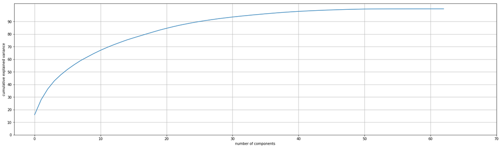

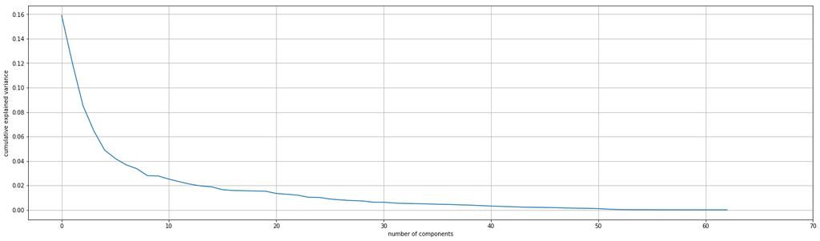

```python
# Investigate the variance accounted for by each principal component.
scree_plot(pca_full)
explain_variance(pca_full)
```

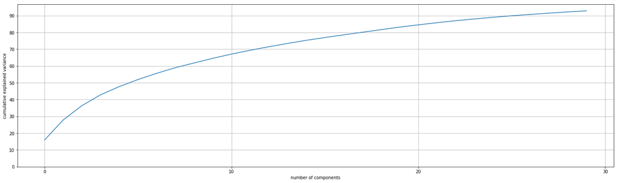

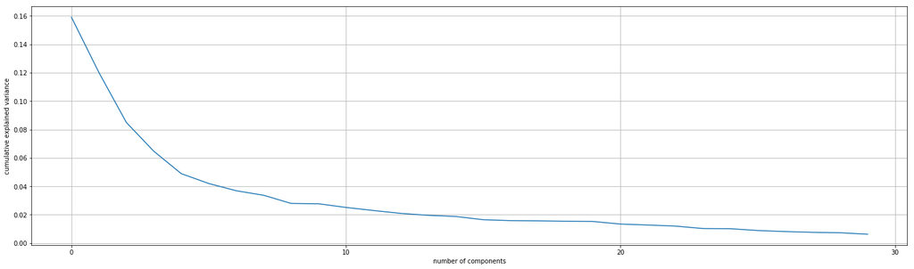

```python
pca_30, X_pca_30 = do_pca(30, imputed_df)
scree_plot(pca_30)
explain_variance(pca_30)
```

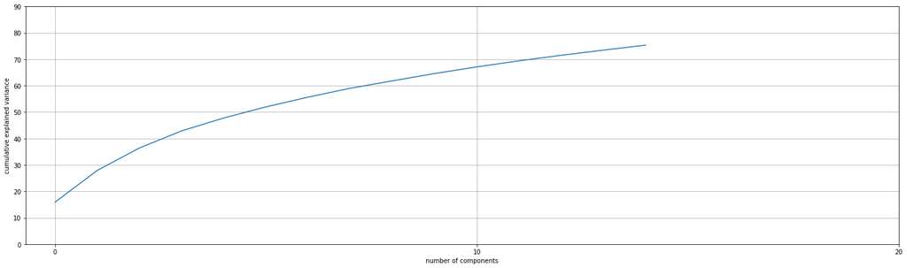

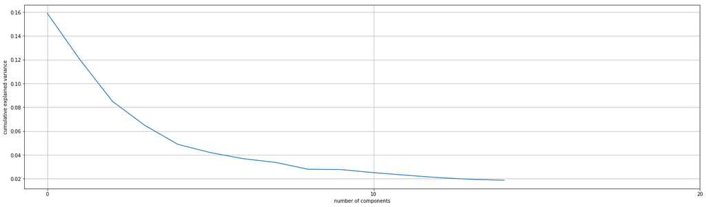

```python
# Re-apply PCA to the data while selecting for number of components to retain.
pca_15, X_pca_15 = do_pca(15, imputed_df)
scree_plot(pca_15)
explain_variance(pca_15)
```

```python
pca_results(imputed_df, pca_15).T
```

|  | Dimension 1 | Dimension 2 | Dimension 3 | Dimension 4 | Dimension 5 | Dimension 6 | Dimension 7 | Dimension 8 | Dimension 9 | Dimension 10 | Dimension 11 | Dimension 12 | Dimension 13 | Dimension 14 | Dimension 15 |
| --- | --- | --- | --- | --- | --- | --- | --- | --- | --- | --- | --- | --- | --- | --- | --- |
| Explained Variance | 0.1590 | 0.1201 | 0.0850 | 0.0647 | 0.0489 | 0.0420 | 0.0369 | 0.0337 | 0.0280 | 0.0277 | 0.0251 | 0.0230 | 0.0209 | 0.0195 | 0.0188 |
| ALTERSKATEGORIE_GROB | -0.0105 | -0.1135 | 0.0179 | -0.0366 | 0.0358 | -0.0848 | 0.0532 | 0.0519 | 0.0437 | -0.0350 | -0.0490 | -0.1022 | 0.1338 | -0.2930 | -0.0053 |
| FINANZ_MINIMALIST | 0.0379 | -0.1919 | 0.2638 | 0.0810 | -0.0656 | 0.1235 | 0.1066 | 0.0000 | -0.0491 | 0.0198 | 0.0336 | -0.0151 | 0.0177 | 0.1743 | -0.0164 |
| FINANZ_SPARER | 0.0187 | 0.2968 | -0.1318 | 0.0437 | -0.0140 | -0.0428 | 0.0058 | 0.0487 | 0.0472 | -0.0295 | -0.0646 | -0.0960 | 0.1389 | -0.2198 | -0.0015 |
| FINANZ_VORSORGER | -0.0318 | -0.2749 | 0.1042 | -0.0781 | 0.0381 | -0.0217 | 0.0123 | -0.0302 | -0.0191 | 0.0063 | 0.0367 | 0.0941 | -0.1711 | 0.2071 | 0.0030 |
| FINANZ_ANLEGER | 0.0207 | 0.2170 | -0.1644 | 0.1415 | -0.0722 | -0.0640 | -0.0009 | 0.1916 | 0.0669 | -0.0286 | -0.0428 | -0.0559 | 0.0654 | -0.2047 | -0.0572 |
| FINANZ_UNAUFFAELLIGER | 0.0698 | 0.2413 | -0.0911 | 0.0919 | -0.0038 | -0.0062 | 0.0521 | 0.0218 | 0.0380 | -0.0434 | -0.0895 | -0.1683 | 0.2239 | -0.1590 | 0.0621 |
| FINANZ_HAUSBAUER | -0.1016 | 0.0027 | -0.1698 | -0.1974 | 0.0981 | -0.1821 | -0.1511 | 0.0110 | 0.0567 | -0.0157 | -0.0270 | 0.0594 | -0.1616 | 0.0362 | 0.0526 |
| HEALTH_TYP | -0.0092 | 0.0268 | -0.0841 | -0.0392 | 0.0807 | -0.2819 | 0.3522 | 0.1252 | 0.0917 | -0.0433 | -0.1274 | -0.1796 | 0.0460 | -0.0355 | 0.0284 |
| RETOURTYP_BK_S | -0.0067 | -0.0634 | 0.0385 | -0.0288 | 0.0368 | 0.0142 | 0.1019 | -0.1354 | 0.6269 | 0.1795 | 0.1060 | 0.1823 | 0.0241 | 0.0342 | -0.0505 |
| SEMIO_SOZ | -0.0156 | 0.1342 | 0.2487 | -0.1295 | 0.0283 | -0.0026 | -0.0377 | -0.0412 | -0.0061 | -0.0085 | 0.0073 | -0.0098 | 0.0305 | -0.0971 | 0.0083 |
| SEMIO_FAM | 0.0191 | 0.2273 | 0.2266 | -0.1133 | 0.0587 | -0.0727 | 0.0427 | -0.0106 | -0.0110 | 0.0026 | 0.0126 | 0.0327 | -0.0494 | 0.0129 | 0.0097 |
| SEMIO_REL | 0.0164 | 0.3053 | 0.0530 | -0.0214 | 0.0128 | -0.0880 | 0.1337 | 0.0275 | 0.0175 | 0.0021 | -0.0451 | -0.0214 | -0.0580 | 0.1523 | 0.0075 |
| SEMIO_MAT | 0.0424 | 0.2036 | 0.0399 | -0.0098 | 0.0292 | -0.0226 | 0.0870 | -0.0575 | -0.0554 | 0.0398 | 0.0407 | 0.1285 | -0.1657 | 0.2270 | 0.0260 |
| SEMIO_VERT | 0.0384 | 0.0503 | 0.3612 | -0.1067 | 0.0595 | -0.0075 | -0.0411 | -0.0123 | -0.0154 | -0.0054 | 0.0289 | 0.0000 | 0.0225 | -0.0965 | 0.0062 |
| SEMIO_LUST | -0.0547 | -0.2008 | 0.0484 | -0.0862 | 0.0252 | -0.1006 | 0.1167 | 0.0068 | 0.0158 | -0.0210 | -0.0729 | -0.0491 | 0.0322 | -0.0581 | 0.0461 |
| SEMIO_ERL | -0.0270 | -0.2636 | -0.1756 | 0.0469 | -0.0077 | -0.0106 | 0.0297 | 0.0249 | 0.0026 | -0.0042 | 0.0017 | -0.0018 | 0.0090 | -0.1204 | -0.0236 |
| SEMIO_KULT | 0.0056 | 0.2565 | 0.2293 | -0.0785 | 0.0118 | -0.0231 | 0.0262 | 0.0041 | -0.0032 | 0.0077 | 0.0019 | 0.0255 | -0.0480 | 0.0613 | -0.0246 |
| SEMIO_RAT | 0.0237 | 0.2051 | -0.2156 | 0.1228 | -0.0527 | 0.0436 | 0.0773 | -0.0309 | -0.0133 | 0.0250 | 0.0067 | 0.0282 | -0.1072 | 0.2679 | 0.0298 |
| SEMIO_KRIT | 0.0098 | -0.1166 | -0.2925 | 0.0948 | -0.0039 | 0.0260 | 0.0092 | -0.0395 | -0.0306 | 0.0125 | 0.0176 | 0.0602 | 0.0322 | 0.0511 | -0.0373 |
| SEMIO_DOM | -0.0267 | -0.0622 | -0.3210 | 0.1217 | -0.0632 | 0.1151 | 0.0469 | -0.0707 | -0.0241 | 0.0200 | 0.0521 | -0.0068 | -0.0237 | 0.1111 | 0.0447 |
| SEMIO_KAEM | -0.0182 | -0.0920 | -0.3596 | 0.1026 | -0.0164 | 0.0689 | 0.0406 | -0.0640 | -0.0090 | 0.0177 | 0.0633 | -0.0205 | -0.0418 | 0.0386 | 0.0446 |
| SEMIO_PFLICHT | 0.0133 | 0.2772 | -0.0878 | 0.0498 | -0.0234 | -0.0217 | 0.1243 | -0.0003 | -0.0018 | 0.0174 | -0.0099 | 0.0155 | -0.0966 | 0.1946 | -0.0012 |
| SEMIO_TRADV | 0.0273 | 0.2660 | -0.0638 | 0.0927 | -0.0594 | 0.0854 | 0.0195 | -0.0485 | -0.0465 | 0.0315 | 0.1185 | 0.0584 | -0.1321 | 0.2447 | 0.0445 |
| ANZ_PERSONEN | 0.0122 | -0.0034 | 0.0745 | 0.1274 | -0.0917 | 0.1482 | 0.0727 | -0.0010 | 0.1293 | -0.0113 | -0.2077 | -0.2631 | -0.3009 | -0.0740 | 0.1885 |
| ANZ_TITEL | -0.0005 | -0.0082 | 0.0087 | -0.0053 | 0.0023 | 0.0154 | 0.0386 | -0.0282 | 0.0022 | -0.0020 | -0.0100 | -0.0802 | 0.0256 | 0.0756 | 0.2121 |
| HH_EINKOMMEN_SCORE | -0.0815 | 0.0807 | -0.1495 | -0.1987 | 0.0860 | -0.1516 | -0.1898 | 0.0106 | -0.0007 | 0.0314 | -0.0844 | 0.3020 | -0.1323 | -0.1473 | -0.1702 |
| W_KEIT_KIND_HH | -0.0023 | 0.0006 | -0.0288 | -0.0430 | 0.0881 | -0.2392 | 0.1224 | 0.1305 | -0.0509 | -0.0439 | 0.3544 | 0.0029 | 0.3430 | 0.1028 | -0.0555 |
| WOHNDAUER_2008 | -0.0470 | -0.0851 | 0.0645 | 0.0369 | -0.0171 | 0.0279 | 0.0900 | 0.0206 | -0.0185 | -0.0460 | -0.0431 | -0.0941 | -0.2310 | 0.0919 | 0.0834 |
| ANZ_HAUSHALTE_AKTIV | -0.0381 | 0.0268 | -0.0717 | -0.1639 | 0.1170 | -0.1036 | -0.0713 | -0.1112 | -0.0338 | 0.0259 | 0.1449 | 0.1006 | 0.1035 | 0.0503 | 0.0851 |
| ... | ... | ... | ... | ... | ... | ... | ... | ... | ... | ... | ... | ... | ... | ... | ... |
| KBA05_ANTG2 | 0.2762 | -0.0228 | -0.0053 | 0.0867 | 0.2098 | -0.0291 | -0.0488 | -0.0704 | -0.0124 | 0.0064 | -0.1281 | 0.0529 | 0.0263 | 0.0251 | -0.0069 |
| KBA05_ANTG3 | 0.2752 | -0.0210 | -0.0096 | 0.0792 | 0.2174 | -0.0333 | -0.0558 | -0.0739 | -0.0115 | 0.0078 | -0.1242 | 0.0544 | 0.0198 | 0.0194 | -0.0088 |
| KBA05_ANTG4 | 0.2759 | -0.0228 | -0.0078 | 0.0800 | 0.2171 | -0.0333 | -0.0522 | -0.0772 | -0.0124 | 0.0081 | -0.1208 | 0.0507 | 0.0249 | 0.0236 | -0.0020 |
| KBA05_GBZ | 0.2791 | -0.0301 | 0.0098 | 0.1107 | 0.1908 | -0.0186 | -0.0361 | -0.0557 | -0.0111 | 0.0051 | -0.1242 | 0.0367 | 0.0379 | 0.0370 | -0.0079 |
| BALLRAUM | 0.0267 | -0.0254 | 0.0588 | 0.1473 | -0.1279 | -0.0499 | -0.0165 | 0.3477 | 0.0095 | -0.0070 | -0.0817 | 0.4014 | 0.0262 | -0.0547 | 0.3630 |
| EWDICHTE | -0.0361 | 0.0297 | -0.0771 | -0.1653 | 0.1189 | 0.0599 | 0.0132 | -0.1533 | -0.0150 | 0.0197 | -0.0162 | 0.1126 | 0.0389 | -0.0377 | 0.4962 |
| INNENSTADT | 0.0341 | -0.0348 | 0.0730 | 0.1788 | -0.1587 | -0.0642 | -0.0036 | 0.3214 | 0.0006 | -0.0140 | -0.0742 | 0.3617 | 0.0447 | -0.0349 | 0.3503 |
| GEBAEUDETYP_RASTER | 0.0312 | -0.0372 | 0.0629 | 0.1581 | -0.1084 | 0.0420 | 0.0306 | 0.2389 | 0.0215 | 0.0055 | -0.0527 | 0.0129 | -0.0081 | 0.1088 | -0.3255 |
| KKK | 0.1638 | -0.0082 | 0.0215 | 0.1304 | 0.1200 | -0.0683 | -0.0206 | 0.1097 | 0.0096 | -0.0141 | 0.5013 | -0.1343 | -0.2479 | -0.1596 | 0.0977 |
| MOBI_REGIO | 0.2790 | -0.0325 | 0.0127 | 0.1159 | 0.1869 | -0.0159 | -0.0332 | -0.0534 | -0.0101 | 0.0039 | -0.1250 | 0.0321 | 0.0391 | 0.0396 | -0.0082 |
| ONLINE_AFFINITAET | 0.0240 | 0.0358 | 0.0278 | 0.0796 | -0.0275 | 0.1033 | 0.0822 | -0.1127 | 0.6477 | 0.1632 | 0.0787 | 0.0987 | 0.0760 | -0.0271 | -0.0160 |
| REGIOTYP | 0.1622 | -0.0066 | 0.0175 | 0.1237 | 0.1254 | -0.0712 | -0.0232 | 0.1065 | 0.0101 | -0.0143 | 0.5027 | -0.1326 | -0.2532 | -0.1655 | 0.0946 |
| KBA13_ANZAHL_PKW | 0.0060 | -0.0170 | 0.0402 | 0.1265 | -0.0400 | -0.0446 | 0.0537 | 0.0223 | 0.0158 | -0.0889 | 0.0913 | -0.0098 | 0.0710 | 0.0077 | 0.1703 |
| PLZ8_ANTG1 | 0.2530 | -0.0246 | -0.0400 | -0.1923 | -0.2317 | 0.0336 | 0.0412 | 0.0456 | 0.0199 | -0.0590 | 0.0173 | -0.0043 | -0.0016 | 0.0112 | -0.0214 |
| PLZ8_ANTG2 | 0.2456 | -0.0142 | -0.0606 | -0.2357 | -0.2047 | 0.0305 | 0.0295 | 0.0134 | 0.0174 | -0.0536 | 0.0182 | 0.0019 | -0.0135 | -0.0034 | -0.0032 |
| PLZ8_ANTG3 | 0.2439 | -0.0120 | -0.0647 | -0.2444 | -0.1982 | 0.0287 | 0.0243 | 0.0069 | 0.0179 | -0.0523 | 0.0222 | 0.0001 | -0.0176 | -0.0067 | 0.0001 |
| PLZ8_ANTG4 | 0.2460 | -0.0138 | -0.0611 | -0.2375 | -0.2032 | 0.0280 | 0.0258 | 0.0120 | 0.0182 | -0.0528 | 0.0233 | -0.0009 | -0.0155 | -0.0043 | -0.0032 |
| PLZ8_HHZ | 0.2489 | -0.0168 | -0.0550 | -0.2218 | -0.2108 | 0.0279 | 0.0359 | 0.0175 | 0.0192 | -0.0617 | 0.0301 | -0.0037 | -0.0039 | 0.0002 | 0.0140 |
| PLZ8_GBZ | 0.2534 | -0.0234 | -0.0418 | -0.1931 | -0.2288 | 0.0302 | 0.0437 | 0.0416 | 0.0199 | -0.0639 | 0.0244 | -0.0028 | 0.0022 | 0.0090 | -0.0015 |
| ARBEIT | -0.0190 | 0.0170 | -0.0466 | -0.1467 | 0.2625 | 0.3622 | 0.0946 | 0.3551 | 0.0261 | -0.0365 | 0.0012 | 0.0403 | 0.0028 | 0.0146 | -0.0498 |
| ORTSGR_KLS9 | -0.0353 | 0.0328 | -0.0842 | -0.2252 | 0.3012 | 0.3475 | 0.0972 | 0.1375 | 0.0105 | -0.0303 | 0.0224 | -0.0537 | 0.0181 | 0.0125 | 0.0261 |
| RELAT_AB | -0.0213 | 0.0182 | -0.0514 | -0.1563 | 0.2625 | 0.3620 | 0.1023 | 0.3343 | 0.0214 | -0.0398 | -0.0031 | 0.0497 | 0.0105 | 0.0060 | -0.0263 |
| GREEN_AVANTGARDE_1 | 0.0098 | -0.0484 | 0.1082 | 0.0742 | -0.0721 | 0.2242 | 0.2193 | -0.1653 | -0.0562 | -0.0066 | -0.0313 | -0.2591 | 0.2433 | 0.0596 | 0.2336 |
| SOHO_KZ_1.0 | 0.0009 | 0.0002 | 0.0023 | 0.0026 | -0.0033 | 0.0026 | 0.0047 | 0.0006 | 0.0021 | -0.0016 | -0.0063 | -0.0064 | -0.0066 | -0.0047 | -0.0068 |
| CAMEO_INTL_2015_WEALTH | 0.0346 | 0.0160 | -0.0473 | -0.1300 | -0.0045 | -0.0446 | -0.0699 | 0.1031 | -0.1144 | 0.6606 | -0.0229 | -0.0761 | -0.0057 | -0.0469 | 0.0442 |
| CAMEO_INTL_2015_LIFE_STAGE | 0.0602 | -0.0320 | 0.0125 | -0.0233 | -0.0711 | 0.0000 | -0.0122 | 0.1441 | -0.1122 | 0.6587 | -0.0206 | -0.1625 | 0.0521 | 0.0271 | 0.0527 |
| PRAEGENDE_JUGENDJAHRE_PERIOD | 0.0274 | 0.2079 | -0.0170 | 0.1240 | -0.1136 | 0.2710 | -0.2548 | -0.0890 | -0.0323 | 0.0024 | 0.0758 | 0.0273 | 0.1517 | -0.1969 | -0.0239 |
| PRAEGENDE_JUGENDJAHRE_DIRECTION_EW | -0.0152 | -0.0162 | 0.0007 | -0.0364 | -0.0079 | -0.0187 | -0.4891 | 0.1675 | 0.1968 | -0.0969 | -0.0406 | -0.2665 | 0.0676 | 0.2418 | 0.1213 |
| PRAEGENDE_JUGENDJAHRE_DIRECTION_W | 0.0144 | 0.0113 | 0.0325 | 0.0743 | -0.0468 | 0.1682 | 0.3547 | -0.2344 | -0.2303 | 0.0935 | 0.1022 | 0.3188 | -0.0154 | -0.2777 | -0.1280 |
| PRAEGENDE_JUGENDJAHRE_DIRECTION_x | 0.0039 | -0.0122 | -0.0720 | -0.0706 | 0.1129 | -0.3264 | 0.3736 | 0.1233 | 0.0534 | -0.0088 | -0.1404 | -0.0906 | -0.0800 | 0.0462 | 0.0186 |

64 rows × 15 columns

### Discussion 2.2: Perform Dimensionality Reduction

At 50 principal components, the accumelated retained information starts to vanish, as it covers almost 95% of the entire features.

### Step 2.3: Interpret Principal Components

Now that we have our transformed principal components, it's a nice idea to check out the weight of each variable on the first few components to see if they can be interpreted in some fashion.

As a reminder, each principal component is a unit vector that points in the direction of highest variance (after accounting for the variance captured by earlier principal components). The further a weight is from zero, the more the principal component is in the direction of the corresponding feature. If two features have large weights of the same sign (both positive or both negative), then increases in one tend expect to be associated with increases in the other. To contrast, features with different signs can be expected to show a negative correlation: increases in one variable should result in a decrease in the other.

- To investigate the features, you should map each weight to their corresponding feature name, then sort the features according to weight. The most interesting features for each principal component, then, will be those at the beginning and end of the sorted list. Use the data dictionary document to help you understand these most prominent features, their relationships, and what a positive or negative value on the principal component might indicate.
- You should investigate and interpret feature associations from the first three principal components in this substep. To help facilitate this, you should write a function that you can call at any time to print the sorted list of feature weights, for the *i*-th principal component. This might come in handy in the next step of the project, when you interpret the tendencies of the discovered clusters.

```python
def pc_weight_per_feature(pca, dataset_df, param=0):
    indexes = [f'{i}' for i in range(1, 16)]
    df = pd.DataFrame(pca.components_, columns=dataset_df.columns, index=indexes)
    df.index.name = 'level'
    if param == 0:
        return df
    else:
        s = df.iloc[param-1].sort_values(ascending=False)
        return s
```

```python
pc_weights = pc_weight_per_feature(pca_15, imputed_df)
pc_weights.head()
```

| level | ALTERSKATEGORIE_GROB | FINANZ_MINIMALIST | FINANZ_SPARER | FINANZ_VORSORGER | FINANZ_ANLEGER | FINANZ_UNAUFFAELLIGER | FINANZ_HAUSBAUER | HEALTH_TYP | RETOURTYP_BK_S | SEMIO_SOZ | ... | ORTSGR_KLS9 | RELAT_AB | GREEN_AVANTGARDE_1 | SOHO_KZ_1.0 | CAMEO_INTL_2015_WEALTH | CAMEO_INTL_2015_LIFE_STAGE | PRAEGENDE_JUGENDJAHRE_PERIOD | PRAEGENDE_JUGENDJAHRE_DIRECTION_EW | PRAEGENDE_JUGENDJAHRE_DIRECTION_W | PRAEGENDE_JUGENDJAHRE_DIRECTION_x |
| --- | --- | --- | --- | --- | --- | --- | --- | --- | --- | --- | --- | --- | --- | --- | --- | --- | --- | --- | --- | --- | --- |
| 1 | -0.010471 | 0.037908 | 0.018687 | -0.031844 | 0.020734 | 0.069758 | -0.101631 | -0.009223 | -0.006750 | -0.015621 | ... | -0.035294 | -0.021336 | 0.009811 | 0.000870 | 0.034571 | 0.060238 | 0.027426 | -0.015204 | 0.014447 | 0.003939 |
| 2 | -0.113542 | -0.191946 | 0.296785 | -0.274921 | 0.216998 | 0.241305 | 0.002745 | 0.026830 | -0.063384 | 0.134207 | ... | 0.032819 | 0.018210 | -0.048370 | 0.000221 | 0.015965 | -0.031986 | 0.207894 | -0.016177 | 0.011345 | -0.012223 |
| 3 | 0.017912 | 0.263759 | -0.131775 | 0.104172 | -0.164387 | -0.091085 | -0.169808 | -0.084089 | 0.038509 | 0.248717 | ... | -0.084195 | -0.051398 | 0.108225 | 0.002258 | -0.047317 | 0.012478 | -0.017046 | 0.000706 | 0.032527 | -0.072044 |
| 4 | -0.036555 | 0.081004 | 0.043654 | -0.078127 | 0.141512 | 0.091926 | -0.197359 | -0.039229 | -0.028783 | -0.129499 | ... | -0.225191 | -0.156343 | 0.074162 | 0.002606 | -0.129963 | -0.023287 | 0.123988 | -0.036422 | 0.074262 | -0.070577 |
| 5 | 0.035753 | -0.065618 | -0.014008 | 0.038090 | -0.072220 | -0.003795 | 0.098074 | 0.080733 | 0.036844 | 0.028285 | ... | 0.301220 | 0.262510 | -0.072103 | -0.003320 | -0.004507 | -0.071143 | -0.113569 | -0.007911 | -0.046802 | 0.112912 |

5 rows × 63 columns

```python
# Map weights for the first principal component to corresponding feature names
# and then print the linked values, sorted by weight.
# HINT: Try defining a function here or in a new cell that you can reuse in the
# other cells.
pc1_weights = pc_weight_per_feature(pca_15, imputed_df, 1)
pc1_top_5 = pc1_weights.keys()[1:6].tolist()
pc1_lower_5 = pc1_weights.keys()[-6:-1].tolist()
print(pc1_weights)
```

```
KBA05_GBZ                             0.279051
MOBI_REGIO                            0.279032
KBA05_ANTG1                           0.278379
KBA05_ANTG2                           0.276162
KBA05_ANTG4                           0.275915
KBA05_ANTG3                           0.275249
PLZ8_GBZ                              0.253396
PLZ8_ANTG1                            0.253007
PLZ8_HHZ                              0.248945
PLZ8_ANTG4                            0.246019
PLZ8_ANTG2                            0.245637
MIN_GEBAEUDEJAHR                      0.245331
PLZ8_ANTG3                            0.243873
KKK                                   0.163845
REGIOTYP                              0.162160
FINANZ_UNAUFFAELLIGER                 0.069758
CAMEO_INTL_2015_LIFE_STAGE            0.060238
KONSUMNAEHE                           0.046347
SEMIO_MAT                             0.042358
SEMIO_VERT                            0.038390
FINANZ_MINIMALIST                     0.037908
CAMEO_INTL_2015_WEALTH                0.034571
INNENSTADT                            0.034074
GEBAEUDETYP_RASTER                    0.031246
PRAEGENDE_JUGENDJAHRE_PERIOD          0.027426
SEMIO_TRADV                           0.027263
BALLRAUM                              0.026654
ONLINE_AFFINITAET                     0.024040
SEMIO_RAT                             0.023728
FINANZ_ANLEGER                        0.020734
                                        ...
PRAEGENDE_JUGENDJAHRE_DIRECTION_W     0.014447
SEMIO_PFLICHT                         0.013295
ANZ_PERSONEN                          0.012174
GREEN_AVANTGARDE_1                    0.009811
SEMIO_KRIT                            0.009760
KBA13_ANZAHL_PKW                      0.006037
SEMIO_KULT                            0.005580
ANZ_HH_TITEL                          0.004872
PRAEGENDE_JUGENDJAHRE_DIRECTION_x     0.003939
SOHO_KZ_1.0                           0.000870
ANZ_TITEL                            -0.000546
W_KEIT_KIND_HH                       -0.002345
RETOURTYP_BK_S                       -0.006750
HEALTH_TYP                           -0.009223
ALTERSKATEGORIE_GROB                 -0.010471
PRAEGENDE_JUGENDJAHRE_DIRECTION_EW   -0.015204
SEMIO_SOZ                            -0.015621
SEMIO_KAEM                           -0.018159
ARBEIT                               -0.019041
RELAT_AB                             -0.021336
SEMIO_DOM                            -0.026699
SEMIO_ERL                            -0.027001
FINANZ_VORSORGER                     -0.031844
ORTSGR_KLS9                          -0.035294
EWDICHTE                             -0.036074
ANZ_HAUSHALTE_AKTIV                  -0.038087
WOHNDAUER_2008                       -0.046956
SEMIO_LUST                           -0.054691
HH_EINKOMMEN_SCORE                   -0.081494
FINANZ_HAUSBAUER                     -0.101631
Name: 1, Length: 63, dtype: float64
```

```python
# Map weights for the second principal component to corresponding feature names
# and then print the linked values, sorted by weight.
pc2_weights = pc_weight_per_feature(pca_15, imputed_df, 2)
pc2_top_5 = pc2_weights.keys()[1:6].tolist()
pc2_lower_5 = pc2_weights.keys()[-6:-1].tolist()
pc2_weights
```

```
SEMIO_REL                             0.305282
FINANZ_SPARER                         0.296785
SEMIO_PFLICHT                         0.277163
SEMIO_TRADV                           0.266050
SEMIO_KULT                            0.256537
FINANZ_UNAUFFAELLIGER                 0.241305
SEMIO_FAM                             0.227324
FINANZ_ANLEGER                        0.216998
PRAEGENDE_JUGENDJAHRE_PERIOD          0.207894
SEMIO_RAT                             0.205085
SEMIO_MAT                             0.203587
SEMIO_SOZ                             0.134207
HH_EINKOMMEN_SCORE                    0.080651
SEMIO_VERT                            0.050275
ONLINE_AFFINITAET                     0.035848
ORTSGR_KLS9                           0.032819
EWDICHTE                              0.029705
HEALTH_TYP                            0.026830
ANZ_HAUSHALTE_AKTIV                   0.026826
RELAT_AB                              0.018210
ARBEIT                                0.017018
CAMEO_INTL_2015_WEALTH                0.015965
PRAEGENDE_JUGENDJAHRE_DIRECTION_W     0.011345
FINANZ_HAUSBAUER                      0.002745
W_KEIT_KIND_HH                        0.000604
SOHO_KZ_1.0                           0.000221
ANZ_PERSONEN                         -0.003405
REGIOTYP                             -0.006553
ANZ_TITEL                            -0.008182
KKK                                  -0.008220
                                        ...
PLZ8_ANTG2                           -0.014237
PRAEGENDE_JUGENDJAHRE_DIRECTION_EW   -0.016177
PLZ8_HHZ                             -0.016755
ANZ_HH_TITEL                         -0.016826
KBA13_ANZAHL_PKW                     -0.016965
MIN_GEBAEUDEJAHR                     -0.019400
KBA05_ANTG3                          -0.020957
KBA05_ANTG4                          -0.022791
KBA05_ANTG2                          -0.022797
PLZ8_GBZ                             -0.023414
PLZ8_ANTG1                           -0.024601
BALLRAUM                             -0.025352
KBA05_GBZ                            -0.030148
KBA05_ANTG1                          -0.031833
CAMEO_INTL_2015_LIFE_STAGE           -0.031986
MOBI_REGIO                           -0.032452
INNENSTADT                           -0.034777
GEBAEUDETYP_RASTER                   -0.037186
KONSUMNAEHE                          -0.044251
GREEN_AVANTGARDE_1                   -0.048370
SEMIO_DOM                            -0.062216
RETOURTYP_BK_S                       -0.063384
WOHNDAUER_2008                       -0.085063
SEMIO_KAEM                           -0.091986
ALTERSKATEGORIE_GROB                 -0.113542
SEMIO_KRIT                           -0.116577
FINANZ_MINIMALIST                    -0.191946
SEMIO_LUST                           -0.200814
SEMIO_ERL                            -0.263630
FINANZ_VORSORGER                     -0.274921
Name: 2, Length: 63, dtype: float64
```

```python
# Map weights for the third principal component to corresponding feature names
# and then print the linked values, sorted by weight.
pc3_weights = pc_weight_per_feature(pca_15, imputed_df, 3)
pc3_top_5 = pc3_weights.keys()[1:6].tolist()
pc3_lower_5 = pc3_weights.keys()[-6:-1].tolist()
pc3_weights
```

```
SEMIO_VERT                           0.361188
FINANZ_MINIMALIST                    0.263759
SEMIO_SOZ                            0.248717
SEMIO_KULT                           0.229338
SEMIO_FAM                            0.226591
GREEN_AVANTGARDE_1                   0.108225
FINANZ_VORSORGER                     0.104172
KONSUMNAEHE                          0.088862
ANZ_PERSONEN                         0.074486
INNENSTADT                           0.072984
WOHNDAUER_2008                       0.064488
GEBAEUDETYP_RASTER                   0.062936
BALLRAUM                             0.058821
SEMIO_REL                            0.052964
SEMIO_LUST                           0.048370
KBA13_ANZAHL_PKW                     0.040171
SEMIO_MAT                            0.039905
RETOURTYP_BK_S                       0.038509
PRAEGENDE_JUGENDJAHRE_DIRECTION_W    0.032527
ONLINE_AFFINITAET                    0.027785
KKK                                  0.021490
ALTERSKATEGORIE_GROB                 0.017912
REGIOTYP                             0.017469
MOBI_REGIO                           0.012694
CAMEO_INTL_2015_LIFE_STAGE           0.012478
ANZ_HH_TITEL                         0.011866
KBA05_ANTG1                          0.010924
MIN_GEBAEUDEJAHR                     0.010546
KBA05_GBZ                            0.009840
ANZ_TITEL                            0.008656
                                       ...
KBA05_ANTG4                         -0.007756
KBA05_ANTG3                         -0.009624
PRAEGENDE_JUGENDJAHRE_PERIOD        -0.017046
W_KEIT_KIND_HH                      -0.028763
PLZ8_ANTG1                          -0.040049
PLZ8_GBZ                            -0.041794
ARBEIT                              -0.046583
CAMEO_INTL_2015_WEALTH              -0.047317
RELAT_AB                            -0.051398
PLZ8_HHZ                            -0.055029
PLZ8_ANTG2                          -0.060570
PLZ8_ANTG4                          -0.061086
SEMIO_TRADV                         -0.063793
PLZ8_ANTG3                          -0.064676
ANZ_HAUSHALTE_AKTIV                 -0.071743
PRAEGENDE_JUGENDJAHRE_DIRECTION_x   -0.072044
EWDICHTE                            -0.077147
HEALTH_TYP                          -0.084089
ORTSGR_KLS9                         -0.084195
SEMIO_PFLICHT                       -0.087799
FINANZ_UNAUFFAELLIGER               -0.091085
FINANZ_SPARER                       -0.131775
HH_EINKOMMEN_SCORE                  -0.149483
FINANZ_ANLEGER                      -0.164387
FINANZ_HAUSBAUER                    -0.169808
SEMIO_ERL                           -0.175608
SEMIO_RAT                           -0.215614
SEMIO_KRIT                          -0.292503
SEMIO_DOM                           -0.321044
SEMIO_KAEM                          -0.359561
Name: 3, Length: 63, dtype: float64
```

```python
pc30_weights = pc_weight_per_feature(pca_15, imputed_df, 15)
pc3_top_5 = pc30_weights.keys()[1:6].tolist()
pc3_lower_5 = pc30_weights.keys()[-6:-1].tolist()
print(pc3_weights)


print('TOP 5:')
print(f'pc1: {pc1_top_5}')
print(f'pc2: {pc2_top_5}')
print(f'pc3: {pc3_top_5}')
print('LOW 5:')
print(f'pc1: {pc1_lower_5}')
print(f'pc2: {pc2_lower_5}')
print(f'pc3: {pc3_lower_5}')
```

```
SEMIO_VERT                           0.361188
FINANZ_MINIMALIST                    0.263759
SEMIO_SOZ                            0.248717
SEMIO_KULT                           0.229338
SEMIO_FAM                            0.226591
GREEN_AVANTGARDE_1                   0.108225
FINANZ_VORSORGER                     0.104172
KONSUMNAEHE                          0.088862
ANZ_PERSONEN                         0.074486
INNENSTADT                           0.072984
WOHNDAUER_2008                       0.064488
GEBAEUDETYP_RASTER                   0.062936
BALLRAUM                             0.058821
SEMIO_REL                            0.052964
SEMIO_LUST                           0.048370
KBA13_ANZAHL_PKW                     0.040171
SEMIO_MAT                            0.039905
RETOURTYP_BK_S                       0.038509
PRAEGENDE_JUGENDJAHRE_DIRECTION_W    0.032527
ONLINE_AFFINITAET                    0.027785
KKK                                  0.021490
ALTERSKATEGORIE_GROB                 0.017912
REGIOTYP                             0.017469
MOBI_REGIO                           0.012694
CAMEO_INTL_2015_LIFE_STAGE           0.012478
ANZ_HH_TITEL                         0.011866
KBA05_ANTG1                          0.010924
MIN_GEBAEUDEJAHR                     0.010546
KBA05_GBZ                            0.009840
ANZ_TITEL                            0.008656
                                       ...
KBA05_ANTG4                         -0.007756
KBA05_ANTG3                         -0.009624
PRAEGENDE_JUGENDJAHRE_PERIOD        -0.017046
W_KEIT_KIND_HH                      -0.028763
PLZ8_ANTG1                          -0.040049
PLZ8_GBZ                            -0.041794
ARBEIT                              -0.046583
CAMEO_INTL_2015_WEALTH              -0.047317
RELAT_AB                            -0.051398
```

[output cut: 15 more lines]

```
FINANZ_HAUSBAUER                    -0.169808
SEMIO_ERL                           -0.175608
SEMIO_RAT                           -0.215614
SEMIO_KRIT                          -0.292503
SEMIO_DOM                           -0.321044
SEMIO_KAEM                          -0.359561
Name: 3, Length: 63, dtype: float64
TOP 5:
pc1: ['MOBI_REGIO', 'KBA05_ANTG1', 'KBA05_ANTG2', 'KBA05_ANTG4', 'KBA05_ANTG3']
pc2: ['FINANZ_SPARER', 'SEMIO_PFLICHT', 'SEMIO_TRADV', 'SEMIO_KULT', 'FINANZ_UNAUFFAELLIGER']
pc3: ['BALLRAUM', 'INNENSTADT', 'GREEN_AVANTGARDE_1', 'ANZ_TITEL', 'ANZ_PERSONEN']
LOW 5:
pc1: ['EWDICHTE', 'ANZ_HAUSHALTE_AKTIV', 'WOHNDAUER_2008', 'SEMIO_LUST', 'HH_EINKOMMEN_SCORE']
pc2: ['ALTERSKATEGORIE_GROB', 'SEMIO_KRIT', 'FINANZ_MINIMALIST', 'SEMIO_LUST', 'SEMIO_ERL']
pc3: ['W_KEIT_KIND_HH', 'FINANZ_ANLEGER', 'PRAEGENDE_JUGENDJAHRE_DIRECTION_W', 'HH_EINKOMMEN_SCORE', 'KONSUMNAEHE']
```

### Discussion 2.3: Interpret Principal Components

Based on the previous results, for every pc level, there are different features that contributes more than others in creating the bigger variance or explain it. The main contributers are the top 5 features and the lower 5 features.

**PC_2** is about financial typology and personality typology. some strong negative feature weights are SEMIO_KRIT,FINANZ_MINIMALIST, SEMIO_LUST and SEMIO_ERL, which indicate the prevalence personality typology, low financial interest rate.

## Step 3: Clustering

### Step 3.1: Apply Clustering to General Population

You've assessed and cleaned the demographics data, then scaled and transformed them. Now, it's time to see how the data clusters in the principal components space. In this substep, you will apply k-means clustering to the dataset and use the average within-cluster distances from each point to their assigned cluster's centroid to decide on a number of clusters to keep.

- Use sklearn's KMeans class to perform k-means clustering on the PCA-transformed data.
- Then, compute the average difference from each point to its assigned cluster's center. **Hint**: The KMeans object's `.score()` method might be useful here, but note that in sklearn, scores tend to be defined so that larger is better. Try applying it to a small, toy dataset, or use an internet search to help your understanding.
- Perform the above two steps for a number of different cluster counts. You can then see how the average distance decreases with an increasing number of clusters. However, each additional cluster provides a smaller net benefit. Use this fact to select a final number of clusters in which to group the data. **Warning**: because of the large size of the dataset, it can take a long time for the algorithm to resolve. The more clusters to fit, the longer the algorithm will take. You should test for cluster counts through at least 10 clusters to get the full picture, but you shouldn't need to test for a number of clusters above about 30.
- Once you've selected a final number of clusters to use, re-fit a KMeans instance to perform the clustering operation. Make sure that you also obtain the cluster assignments for the general demographics data, since you'll be using them in the final Step 3.3.

```python
def kmeans_score(data,center):
    kmeans = KMeans(n_clusters=center,random_state=42)
    model = kmeans.fit(data)
    score = np.abs(model.score(data))
    return model,score
```

```python
# Over a number of different cluster counts...
# run k-means clustering on the data and...
# compute the average within-cluster distances.

scores=[]
models=[]

centers =list(range(1,27,3))

for c in centers :
    model, score = kmeans_score(X_pca_15,c)
    labels = model.predict(X_pca_15)
    scores.append(score)
    models.append(model)
```

```
Text(0.5,1,'SSE vs. K')
```

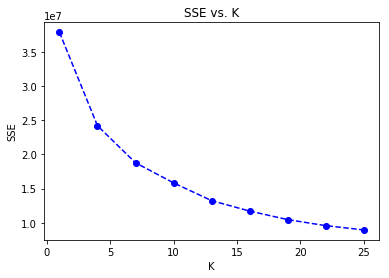

```python
# Investigate the change in within-cluster distance across number of clusters.
# HINT: Use matplotlib's plot function to visualize this relationship.
plt.plot(centers, scores, linestyle='--', marker='o', color='b');
plt.xlabel('K');
plt.ylabel('SSE');
plt.title('SSE vs. K')
```

```python
# Re-fit the k-means model with the selected number of clusters and obtain
# cluster predictions for the general population demographics data.

kmeans = KMeans(n_clusters=15)
model = kmeans.fit(X_pca_15)
predictions = model.predict(X_pca_15)
```

### Discussion 3.1: Apply Clustering to General Population

Based on this result, i decided for 15 clusters

### Step 3.2: Apply All Steps to the Customer Data

Now that you have clusters and cluster centers for the general population, it's time to see how the customer data maps on to those clusters. Take care to not confuse this for re-fitting all of the models to the customer data. Instead, you're going to use the fits from the general population to clean, transform, and cluster the customer data. In the last step of the project, you will interpret how the general population fits apply to the customer data.

- Don't forget when loading in the customers data, that it is semicolon (`;`) delimited.
- Apply the same feature wrangling, selection, and engineering steps to the customer demographics using the `clean_data()` function you created earlier. (You can assume that the customer demographics data has similar meaning behind missing data patterns as the general demographics data.)
- Use the sklearn objects from the general demographics data, and apply their transformations to the customers data. That is, you should not be using a `.fit()` or `.fit_transform()` method to re-fit the old objects, nor should you be creating new sklearn objects! Carry the data through the feature scaling, PCA, and clustering steps, obtaining cluster assignments for all of the data in the customer demographics data.

```python
# Load in the customer demographics data.
customers = pd.read_csv('Udacity_CUSTOMERS_Subset.csv', delimiter=';')
print(customers.shape)
customers.head()
```

```
(191652, 85)
```

|  | AGER_TYP | ALTERSKATEGORIE_GROB | ANREDE_KZ | CJT_GESAMTTYP | FINANZ_MINIMALIST | FINANZ_SPARER | FINANZ_VORSORGER | FINANZ_ANLEGER | FINANZ_UNAUFFAELLIGER | FINANZ_HAUSBAUER | ... | PLZ8_ANTG1 | PLZ8_ANTG2 | PLZ8_ANTG3 | PLZ8_ANTG4 | PLZ8_BAUMAX | PLZ8_HHZ | PLZ8_GBZ | ARBEIT | ORTSGR_KLS9 | RELAT_AB |
| --- | --- | --- | --- | --- | --- | --- | --- | --- | --- | --- | --- | --- | --- | --- | --- | --- | --- | --- | --- | --- | --- |
| 0 | 2 | 4 | 1 | 5.0 | 5 | 1 | 5 | 1 | 2 | 2 | ... | 3.0 | 3.0 | 1.0 | 0.0 | 1.0 | 5.0 | 5.0 | 1.0 | 2.0 | 1.0 |
| 1 | -1 | 4 | 1 | NaN | 5 | 1 | 5 | 1 | 3 | 2 | ... | NaN | NaN | NaN | NaN | NaN | NaN | NaN | NaN | NaN | NaN |
| 2 | -1 | 4 | 2 | 2.0 | 5 | 1 | 5 | 1 | 4 | 4 | ... | 2.0 | 3.0 | 3.0 | 1.0 | 3.0 | 3.0 | 2.0 | 3.0 | 5.0 | 3.0 |
| 3 | 1 | 4 | 1 | 2.0 | 5 | 1 | 5 | 2 | 1 | 2 | ... | 3.0 | 2.0 | 1.0 | 0.0 | 1.0 | 3.0 | 4.0 | 1.0 | 3.0 | 1.0 |
| 4 | -1 | 3 | 1 | 6.0 | 3 | 1 | 4 | 4 | 5 | 2 | ... | 2.0 | 4.0 | 2.0 | 1.0 | 2.0 | 3.0 | 3.0 | 3.0 | 5.0 | 1.0 |

5 rows × 85 columns

```python
# Apply preprocessing, feature transformation, and clustering from the general
# demographics onto the customer data, obtaining cluster predictions for the
# customer demographics data.
clean_customers_df =clean_data(customers)
print(clean_customers_df.shape)
clean_customers_df.head()
```

```
missing values for [PRAEGENDE_JUGENDJAHRE_PERIOD]:  1290
missing values for [PRAEGENDE_JUGENDJAHRE_DIRECTION]:  1290
(141661, 63)
```

|  | ALTERSKATEGORIE_GROB | FINANZ_MINIMALIST | FINANZ_SPARER | FINANZ_VORSORGER | FINANZ_ANLEGER | FINANZ_UNAUFFAELLIGER | FINANZ_HAUSBAUER | HEALTH_TYP | RETOURTYP_BK_S | SEMIO_SOZ | ... | ORTSGR_KLS9 | RELAT_AB | GREEN_AVANTGARDE_1 | SOHO_KZ_1.0 | CAMEO_INTL_2015_WEALTH | CAMEO_INTL_2015_LIFE_STAGE | PRAEGENDE_JUGENDJAHRE_PERIOD | PRAEGENDE_JUGENDJAHRE_DIRECTION_EW | PRAEGENDE_JUGENDJAHRE_DIRECTION_W | PRAEGENDE_JUGENDJAHRE_DIRECTION_x |
| --- | --- | --- | --- | --- | --- | --- | --- | --- | --- | --- | --- | --- | --- | --- | --- | --- | --- | --- | --- | --- | --- |
| 0 | 4.0 | 5 | 1 | 5 | 1 | 2 | 2 | 1.0 | 5.0 | 6 | ... | 2.0 | 1.0 | 1 | 0 | 1.0 | 3.0 | 50.0 | 1 | 0 | 0 |
| 1 | 4.0 | 5 | 1 | 5 | 1 | 4 | 4 | 2.0 | 5.0 | 2 | ... | 5.0 | 3.0 | 1 | 0 | 3.0 | 4.0 | 50.0 | 1 | 0 | 0 |
| 2 | 4.0 | 5 | 1 | 5 | 2 | 1 | 2 | 2.0 | 3.0 | 6 | ... | 3.0 | 1.0 | 0 | 0 | 2.0 | 4.0 | 40.0 | 1 | 0 | 0 |
| 3 | 3.0 | 3 | 1 | 4 | 4 | 5 | 2 | 3.0 | 5.0 | 4 | ... | 5.0 | 1.0 | 0 | 0 | 4.0 | 1.0 | 70.0 | 1 | 0 | 0 |
| 4 | 3.0 | 5 | 1 | 5 | 1 | 2 | 3 | 3.0 | 3.0 | 6 | ... | 7.0 | 5.0 | 1 | 0 | 3.0 | 4.0 | 50.0 | 1 | 0 | 0 |

5 rows × 63 columns

```python
clean_customers_df[clean_customers_df.columns].shape
fill_NaN = Imputer(missing_values=np.nan, strategy='mean', axis=1)
df = pd.DataFrame(fill_NaN.transform(clean_customers_df))
df.columns = clean_customers_df.columns
df.index = clean_customers_df.index
```

```python
df[df.columns] = scaler.transform(df[df.columns].as_matrix())

#transform the customers data using pca object
X_customer_pca = pca_15.transform(df)
#predict clustering using the kmeans object
predict_customers = model.predict(X_customer_pca)
```

### Step 3.3: Compare Customer Data to Demographics Data

At this point, you have clustered data based on demographics of the general population of Germany, and seen how the customer data for a mail-order sales company maps onto those demographic clusters. In this final substep, you will compare the two cluster distributions to see where the strongest customer base for the company is.

Consider the proportion of persons in each cluster for the general population, and the proportions for the customers. If we think the company's customer base to be universal, then the cluster assignment proportions should be fairly similar between the two. If there are only particular segments of the population that are interested in the company's products, then we should see a mismatch from one to the other. If there is a higher proportion of persons in a cluster for the customer data compared to the general population (e.g. 5% of persons are assigned to a cluster for the general population, but 15% of the customer data is closest to that cluster's centroid) then that suggests the people in that cluster to be a target audience for the company. On the other hand, the proportion of the data in a cluster being larger in the general population than the customer data (e.g. only 2% of customers closest to a population centroid that captures 6% of the data) suggests that group of persons to be outside of the target demographics.

Take a look at the following points in this step:

- Compute the proportion of data points in each cluster for the general population and the customer data. Visualizations will be useful here: both for the individual dataset proportions, but also to visualize the ratios in cluster representation between groups. Seaborn's [`countplot()`](https://seaborn.pydata.org/generated/seaborn.countplot.html) or [`barplot()`](https://seaborn.pydata.org/generated/seaborn.barplot.html) function could be handy.
  - Recall the analysis you performed in step 1.1.3 of the project, where you separated out certain data points from the dataset if they had more than a specified threshold of missing values. If you found that this group was qualitatively different from the main bulk of the data, you should treat this as an additional data cluster in this analysis. Make sure that you account for the number of data points in this subset, for both the general population and customer datasets, when making your computations!
- Which cluster or clusters are overrepresented in the customer dataset compared to the general population? Select at least one such cluster and infer what kind of people might be represented by that cluster. Use the principal component interpretations from step 2.3 or look at additional components to help you make this inference. Alternatively, you can use the `.inverse_transform()` method of the PCA and StandardScaler objects to transform centroids back to the original data space and interpret the retrieved values directly.
- Perform a similar investigation for the underrepresented clusters. Which cluster or clusters are underrepresented in the customer dataset compared to the general population, and what kinds of people are typified by these clusters?

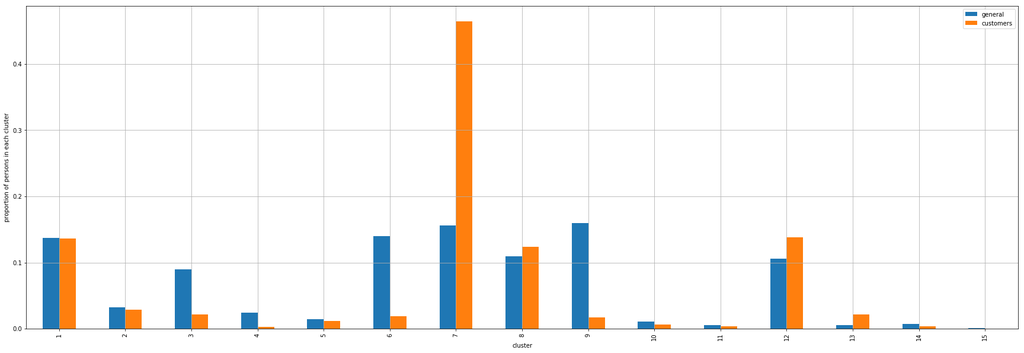

```python
# Compare the proportion of data in each cluster for the customer data to the
# proportion of data in each cluster for the general population.

general_prop = []
customers_prop = []
x = [i+1 for i in range(15)]
for i in range(15):
    general_prop.append((predictions == i).sum()/len(predictions))
    customers_prop.append((predict_customers == i).sum()/len(predict_customers))



fig, ax = plt.subplots()
df_general = pd.DataFrame({'cluster' : x, 'general' : general_prop, 'customers':customers_prop})
df_general.plot(x='cluster', y = ['general', 'customers'], kind='bar', figsize=(30,10), ax=ax)
plt.ylabel('proportion of persons in each cluster')
ax.grid()
plt.show()
```

```python
# What kinds of people are part of a cluster that is overrepresented in the
# customer data compared to the general population?
#Cluster 7
data1_7 = scaler.inverse_transform(pca_15.inverse_transform(X_customer_pca[np.where(predict_customers==6)])).round()

df = pd.DataFrame(data=data1_7,
          index=np.array(range(0, data1_7.shape[0])),
          columns=df.columns)
df.head(20)
```

|  | ALTERSKATEGORIE_GROB | FINANZ_MINIMALIST | FINANZ_SPARER | FINANZ_VORSORGER | FINANZ_ANLEGER | FINANZ_UNAUFFAELLIGER | FINANZ_HAUSBAUER | HEALTH_TYP | RETOURTYP_BK_S | SEMIO_SOZ | ... | ORTSGR_KLS9 | RELAT_AB | GREEN_AVANTGARDE_1 | SOHO_KZ_1.0 | CAMEO_INTL_2015_WEALTH | CAMEO_INTL_2015_LIFE_STAGE | PRAEGENDE_JUGENDJAHRE_PERIOD | PRAEGENDE_JUGENDJAHRE_DIRECTION_EW | PRAEGENDE_JUGENDJAHRE_DIRECTION_W | PRAEGENDE_JUGENDJAHRE_DIRECTION_x |
| --- | --- | --- | --- | --- | --- | --- | --- | --- | --- | --- | --- | --- | --- | --- | --- | --- | --- | --- | --- | --- | --- |
| 0 | 4.0 | 6.0 | 1.0 | 5.0 | 1.0 | 2.0 | 2.0 | 4.0 | 5.0 | 6.0 | ... | 2.0 | 0.0 | 1.0 | 0.0 | 0.0 | 3.0 | 55.0 | 1.0 | -0.0 | 0.0 |
| 1 | 1.0 | 6.0 | 0.0 | 5.0 | 0.0 | 2.0 | 2.0 | 2.0 | 5.0 | 5.0 | ... | 2.0 | 1.0 | 1.0 | -0.0 | 2.0 | 4.0 | 51.0 | 1.0 | -0.0 | -0.0 |
| 2 | 3.0 | 5.0 | 1.0 | 5.0 | 1.0 | 2.0 | 2.0 | 3.0 | 3.0 | 5.0 | ... | 6.0 | 4.0 | 1.0 | 0.0 | 2.0 | 4.0 | 59.0 | 1.0 | -0.0 | 0.0 |
| 3 | 4.0 | 6.0 | 1.0 | 5.0 | 1.0 | 2.0 | 2.0 | 3.0 | 5.0 | 5.0 | ... | 3.0 | 2.0 | 1.0 | 0.0 | 1.0 | 3.0 | 58.0 | 1.0 | -0.0 | 0.0 |
| 4 | 4.0 | 6.0 | 1.0 | 5.0 | 1.0 | 2.0 | 2.0 | 4.0 | 5.0 | 6.0 | ... | 5.0 | 3.0 | 1.0 | 0.0 | 2.0 | 4.0 | 55.0 | 1.0 | 0.0 | 0.0 |
| 5 | 4.0 | 5.0 | 2.0 | 4.0 | 2.0 | 3.0 | 1.0 | 2.0 | 3.0 | 5.0 | ... | 6.0 | 3.0 | 1.0 | 0.0 | 2.0 | 4.0 | 74.0 | 1.0 | 0.0 | -0.0 |
| 6 | 3.0 | 5.0 | 2.0 | 4.0 | 1.0 | 2.0 | 2.0 | 3.0 | 6.0 | 6.0 | ... | 4.0 | 1.0 | 1.0 | 0.0 | 2.0 | 3.0 | 64.0 | 1.0 | 0.0 | 0.0 |
| 7 | 4.0 | 5.0 | 2.0 | 4.0 | 3.0 | 2.0 | 2.0 | 2.0 | 3.0 | 5.0 | ... | 1.0 | 0.0 | 0.0 | 0.0 | 1.0 | 2.0 | 69.0 | 1.0 | 0.0 | -0.0 |
| 8 | 2.0 | 6.0 | 1.0 | 5.0 | 1.0 | 2.0 | 1.0 | 3.0 | 4.0 | 5.0 | ... | 5.0 | 2.0 | 1.0 | 0.0 | 1.0 | 4.0 | 60.0 | 0.0 | 1.0 | 0.0 |
| 9 | 3.0 | 5.0 | 1.0 | 5.0 | 1.0 | 2.0 | 2.0 | 5.0 | 4.0 | 6.0 | ... | 5.0 | 3.0 | 1.0 | 0.0 | 2.0 | 4.0 | 56.0 | 1.0 | 0.0 | 0.0 |
| 10 | 6.0 | 4.0 | 4.0 | 2.0 | 4.0 | 5.0 | 1.0 | 7.0 | 3.0 | 6.0 | ... | 3.0 | 0.0 | 1.0 | 0.0 | 0.0 | 4.0 | 91.0 | 1.0 | -0.0 | -0.0 |
| 11 | 2.0 | 5.0 | 2.0 | 4.0 | 1.0 | 3.0 | 2.0 | 2.0 | 5.0 | 5.0 | ... | 7.0 | 4.0 | 1.0 | 0.0 | 3.0 | 5.0 | 69.0 | 1.0 | 0.0 | -0.0 |
| 12 | 4.0 | 5.0 | 2.0 | 4.0 | 3.0 | 3.0 | 1.0 | 4.0 | 4.0 | 5.0 | ... | 2.0 | 1.0 | 1.0 | 0.0 | 2.0 | 4.0 | 75.0 | 1.0 | -0.0 | -0.0 |
| 13 | 3.0 | 5.0 | 1.0 | 5.0 | 1.0 | 2.0 | 2.0 | 5.0 | 4.0 | 6.0 | ... | 5.0 | 2.0 | 1.0 | 0.0 | 3.0 | 4.0 | 52.0 | 1.0 | -0.0 | 0.0 |
| 14 | 1.0 | 5.0 | 1.0 | 5.0 | 2.0 | 1.0 | 2.0 | -1.0 | 4.0 | 5.0 | ... | 1.0 | 1.0 | 0.0 | 0.0 | 0.0 | 3.0 | 65.0 | 1.0 | 0.0 | -0.0 |
| 15 | 4.0 | 6.0 | 1.0 | 4.0 | 1.0 | 2.0 | 1.0 | 3.0 | 3.0 | 6.0 | ... | 5.0 | 2.0 | 1.0 | 0.0 | 2.0 | 4.0 | 63.0 | -0.0 | 1.0 | 0.0 |
| 16 | 4.0 | 5.0 | 1.0 | 5.0 | 1.0 | 1.0 | 3.0 | 3.0 | 4.0 | 5.0 | ... | 2.0 | 1.0 | 0.0 | 0.0 | 2.0 | 3.0 | 48.0 | 1.0 | 0.0 | 0.0 |
| 17 | 4.0 | 6.0 | 1.0 | 5.0 | 0.0 | 2.0 | 1.0 | 5.0 | 2.0 | 5.0 | ... | 5.0 | 2.0 | 1.0 | 0.0 | 3.0 | 5.0 | 56.0 | 0.0 | 1.0 | 0.0 |
| 18 | 3.0 | 5.0 | 1.0 | 5.0 | 1.0 | 1.0 | 2.0 | 1.0 | 4.0 | 5.0 | ... | 2.0 | 1.0 | 0.0 | 0.0 | 2.0 | 3.0 | 55.0 | 1.0 | 0.0 | 0.0 |
| 19 | 3.0 | 5.0 | 1.0 | 5.0 | 2.0 | 2.0 | 2.0 | 1.0 | 5.0 | 4.0 | ... | 2.0 | 2.0 | 0.0 | 0.0 | 2.0 | 4.0 | 61.0 | 1.0 | -0.0 | -0.0 |

20 rows × 63 columns

```python
# What kinds of people are part of a cluster that is underrepresented in the
# customer data compared to the general population?
data2_7 = scaler.inverse_transform(pca_15.inverse_transform(X_pca_15[np.where(predictions==6)])).round()

df = pd.DataFrame(data=data2_7,
          index=np.array(range(0, data2_7.shape[0])),
          columns=df.columns)
df.head(20)
```

|  | ALTERSKATEGORIE_GROB | FINANZ_MINIMALIST | FINANZ_SPARER | FINANZ_VORSORGER | FINANZ_ANLEGER | FINANZ_UNAUFFAELLIGER | FINANZ_HAUSBAUER | HEALTH_TYP | RETOURTYP_BK_S | SEMIO_SOZ | ... | ORTSGR_KLS9 | RELAT_AB | GREEN_AVANTGARDE_1 | SOHO_KZ_1.0 | CAMEO_INTL_2015_WEALTH | CAMEO_INTL_2015_LIFE_STAGE | PRAEGENDE_JUGENDJAHRE_PERIOD | PRAEGENDE_JUGENDJAHRE_DIRECTION_EW | PRAEGENDE_JUGENDJAHRE_DIRECTION_W | PRAEGENDE_JUGENDJAHRE_DIRECTION_x |
| --- | --- | --- | --- | --- | --- | --- | --- | --- | --- | --- | --- | --- | --- | --- | --- | --- | --- | --- | --- | --- | --- |
| 0 | 4.0 | 4.0 | 2.0 | 4.0 | 2.0 | 2.0 | 3.0 | 3.0 | 6.0 | 6.0 | ... | 7.0 | 5.0 | 0.0 | 0.0 | 4.0 | 4.0 | 70.0 | 1.0 | -0.0 | -0.0 |
| 1 | 5.0 | 4.0 | 3.0 | 3.0 | 3.0 | 3.0 | 1.0 | 4.0 | 3.0 | 5.0 | ... | 5.0 | 2.0 | 1.0 | 0.0 | 2.0 | 3.0 | 85.0 | 0.0 | 1.0 | -0.0 |
| 2 | 3.0 | 5.0 | 2.0 | 4.0 | 2.0 | 3.0 | 2.0 | 2.0 | 3.0 | 5.0 | ... | 6.0 | 3.0 | 1.0 | 0.0 | 3.0 | 4.0 | 73.0 | 1.0 | 0.0 | -0.0 |
| 3 | 4.0 | 4.0 | 3.0 | 3.0 | 3.0 | 2.0 | 2.0 | 2.0 | 3.0 | 5.0 | ... | 3.0 | 2.0 | 0.0 | 0.0 | 2.0 | 1.0 | 76.0 | -0.0 | 1.0 | -0.0 |
| 4 | 3.0 | 5.0 | 1.0 | 5.0 | 1.0 | 1.0 | 3.0 | 0.0 | 4.0 | 5.0 | ... | 4.0 | 3.0 | 0.0 | 0.0 | 3.0 | 4.0 | 57.0 | 1.0 | -0.0 | 0.0 |
| 5 | 3.0 | 5.0 | 1.0 | 5.0 | 1.0 | 1.0 | 3.0 | 1.0 | 5.0 | 5.0 | ... | 6.0 | 4.0 | 0.0 | 0.0 | 3.0 | 4.0 | 59.0 | 1.0 | -0.0 | -0.0 |
| 6 | 2.0 | 5.0 | 2.0 | 4.0 | 2.0 | 3.0 | 1.0 | 2.0 | 4.0 | 4.0 | ... | 4.0 | 2.0 | 1.0 | 0.0 | 1.0 | 4.0 | 77.0 | 0.0 | 1.0 | -0.0 |
| 7 | 3.0 | 4.0 | 1.0 | 5.0 | 2.0 | 1.0 | 3.0 | -0.0 | 5.0 | 5.0 | ... | 3.0 | 2.0 | 0.0 | 0.0 | 3.0 | 4.0 | 59.0 | 1.0 | -0.0 | -0.0 |
| 8 | 3.0 | 5.0 | 1.0 | 5.0 | 1.0 | 2.0 | 2.0 | 3.0 | 4.0 | 6.0 | ... | 6.0 | 4.0 | 1.0 | 0.0 | 4.0 | 6.0 | 58.0 | 1.0 | -0.0 | 0.0 |
| 9 | 4.0 | 5.0 | 1.0 | 5.0 | 2.0 | 1.0 | 3.0 | 3.0 | 5.0 | 5.0 | ... | 2.0 | 2.0 | 0.0 | 0.0 | 3.0 | 4.0 | 52.0 | 1.0 | 0.0 | 0.0 |
| 10 | 5.0 | 5.0 | 2.0 | 4.0 | 3.0 | 2.0 | 2.0 | 2.0 | 3.0 | 5.0 | ... | 3.0 | 3.0 | 0.0 | 0.0 | 3.0 | 4.0 | 72.0 | -0.0 | 1.0 | -0.0 |
| 11 | 4.0 | 5.0 | 2.0 | 4.0 | 2.0 | 3.0 | 2.0 | 3.0 | 5.0 | 6.0 | ... | 7.0 | 4.0 | 1.0 | 0.0 | 2.0 | 4.0 | 72.0 | 1.0 | 0.0 | -0.0 |
| 12 | 4.0 | 5.0 | 2.0 | 4.0 | 2.0 | 3.0 | 1.0 | 2.0 | 5.0 | 5.0 | ... | 2.0 | 0.0 | 1.0 | 0.0 | 2.0 | 4.0 | 77.0 | -0.0 | 1.0 | -0.0 |
| 13 | 7.0 | 2.0 | 4.0 | 2.0 | 4.0 | 4.0 | 3.0 | 5.0 | 4.0 | 5.0 | ... | 2.0 | 1.0 | 0.0 | 0.0 | 3.0 | 3.0 | 87.0 | 1.0 | -0.0 | -0.0 |
| 14 | 3.0 | 4.0 | 1.0 | 5.0 | 1.0 | 1.0 | 3.0 | 2.0 | 5.0 | 5.0 | ... | 6.0 | 4.0 | 0.0 | 0.0 | 2.0 | 2.0 | 56.0 | 1.0 | 0.0 | 0.0 |
| 15 | 3.0 | 5.0 | 1.0 | 5.0 | 1.0 | 1.0 | 2.0 | 4.0 | 4.0 | 4.0 | ... | 4.0 | 3.0 | 1.0 | 0.0 | 2.0 | 5.0 | 53.0 | 1.0 | -0.0 | 0.0 |
| 16 | 3.0 | 4.0 | 2.0 | 4.0 | 2.0 | 2.0 | 2.0 | 2.0 | 4.0 | 5.0 | ... | 4.0 | 2.0 | 0.0 | 0.0 | 3.0 | 3.0 | 74.0 | -0.0 | 1.0 | 0.0 |
| 17 | 3.0 | 4.0 | 2.0 | 4.0 | 1.0 | 2.0 | 2.0 | 3.0 | 4.0 | 5.0 | ... | 8.0 | 4.0 | 1.0 | 0.0 | 3.0 | 4.0 | 68.0 | 1.0 | 0.0 | -0.0 |
| 18 | 4.0 | 5.0 | 1.0 | 5.0 | 1.0 | 2.0 | 2.0 | 4.0 | 5.0 | 5.0 | ... | 8.0 | 4.0 | 1.0 | 0.0 | 2.0 | 4.0 | 53.0 | 1.0 | -0.0 | 0.0 |
| 19 | 2.0 | 4.0 | 1.0 | 5.0 | 2.0 | 1.0 | 3.0 | -0.0 | 2.0 | 5.0 | ... | 3.0 | 2.0 | -0.0 | 0.0 | 4.0 | 4.0 | 61.0 | 1.0 | -0.0 | 0.0 |

20 rows × 63 columns

```python
#Cluster 9
data_1_9 = scaler.inverse_transform(pca_15.inverse_transform(X_customer_pca[np.where(predict_customers==8)])).round()

df = pd.DataFrame(data=data_1_9,
          index=np.array(range(0, data_1_9.shape[0])),
          columns=df.columns)
df.head(20)
```

|  | ALTERSKATEGORIE_GROB | FINANZ_MINIMALIST | FINANZ_SPARER | FINANZ_VORSORGER | FINANZ_ANLEGER | FINANZ_UNAUFFAELLIGER | FINANZ_HAUSBAUER | HEALTH_TYP | RETOURTYP_BK_S | SEMIO_SOZ | ... | ORTSGR_KLS9 | RELAT_AB | GREEN_AVANTGARDE_1 | SOHO_KZ_1.0 | CAMEO_INTL_2015_WEALTH | CAMEO_INTL_2015_LIFE_STAGE | PRAEGENDE_JUGENDJAHRE_PERIOD | PRAEGENDE_JUGENDJAHRE_DIRECTION_EW | PRAEGENDE_JUGENDJAHRE_DIRECTION_W | PRAEGENDE_JUGENDJAHRE_DIRECTION_x |
| --- | --- | --- | --- | --- | --- | --- | --- | --- | --- | --- | --- | --- | --- | --- | --- | --- | --- | --- | --- | --- | --- |
| 0 | -1.0 | 2.0 | 2.0 | 4.0 | 1.0 | 2.0 | 5.0 | 0.0 | 3.0 | 4.0 | ... | 9.0 | 3.0 | 0.0 | 0.0 | 4.0 | 1.0 | 61.0 | 1.0 | -0.0 | 0.0 |
| 1 | 1.0 | 3.0 | 3.0 | 3.0 | 3.0 | 3.0 | 3.0 | -2.0 | 4.0 | 3.0 | ... | 5.0 | 2.0 | 0.0 | 0.0 | 3.0 | 2.0 | 86.0 | -0.0 | 1.0 | -0.0 |
| 2 | 1.0 | 3.0 | 4.0 | 2.0 | 5.0 | 4.0 | 2.0 | 3.0 | 3.0 | 3.0 | ... | 3.0 | 1.0 | 0.0 | 0.0 | 2.0 | 3.0 | 92.0 | 1.0 | -0.0 | -0.0 |
| 3 | 1.0 | 4.0 | 4.0 | 2.0 | 5.0 | 4.0 | 1.0 | 6.0 | 2.0 | 4.0 | ... | 4.0 | 3.0 | 1.0 | 0.0 | 2.0 | 5.0 | 89.0 | 1.0 | -0.0 | 0.0 |
| 4 | -1.0 | 3.0 | 1.0 | 5.0 | 1.0 | 1.0 | 5.0 | -1.0 | 3.0 | 3.0 | ... | 8.0 | 4.0 | -0.0 | 0.0 | 3.0 | 1.0 | 58.0 | 1.0 | -0.0 | 0.0 |
| 5 | 1.0 | 1.0 | 5.0 | 2.0 | 5.0 | 4.0 | 4.0 | 5.0 | 1.0 | 3.0 | ... | 6.0 | 4.0 | 0.0 | 0.0 | 2.0 | 2.0 | 91.0 | 1.0 | -0.0 | -0.0 |
| 6 | 0.0 | 3.0 | 4.0 | 2.0 | 4.0 | 4.0 | 2.0 | 2.0 | 3.0 | 4.0 | ... | 3.0 | 3.0 | 0.0 | 0.0 | 2.0 | 3.0 | 89.0 | 1.0 | 0.0 | -0.0 |
| 7 | -1.0 | 3.0 | 2.0 | 4.0 | 2.0 | 2.0 | 5.0 | 2.0 | 4.0 | 4.0 | ... | 7.0 | 4.0 | 0.0 | 0.0 | 4.0 | 2.0 | 60.0 | 1.0 | -0.0 | 0.0 |
| 8 | 1.0 | 2.0 | 4.0 | 2.0 | 5.0 | 4.0 | 3.0 | 2.0 | 4.0 | 2.0 | ... | 6.0 | 4.0 | 0.0 | 0.0 | 3.0 | 3.0 | 93.0 | 1.0 | -0.0 | -0.0 |
| 9 | -0.0 | 4.0 | 3.0 | 3.0 | 4.0 | 3.0 | 2.0 | 3.0 | 3.0 | 3.0 | ... | 1.0 | 1.0 | 0.0 | 0.0 | 3.0 | 4.0 | 78.0 | -0.0 | 1.0 | 0.0 |
| 10 | 1.0 | 1.0 | 4.0 | 2.0 | 4.0 | 3.0 | 4.0 | 1.0 | 3.0 | 3.0 | ... | 6.0 | 2.0 | 0.0 | 0.0 | 5.0 | 4.0 | 87.0 | 1.0 | -0.0 | -0.0 |
| 11 | 1.0 | 1.0 | 4.0 | 2.0 | 4.0 | 4.0 | 4.0 | 5.0 | 3.0 | 3.0 | ... | 8.0 | 5.0 | 0.0 | 0.0 | 3.0 | 2.0 | 83.0 | 1.0 | -0.0 | 0.0 |
| 12 | 1.0 | 1.0 | 4.0 | 2.0 | 3.0 | 4.0 | 4.0 | 4.0 | 2.0 | 3.0 | ... | 9.0 | 4.0 | 1.0 | 0.0 | 4.0 | 3.0 | 87.0 | 1.0 | -0.0 | -0.0 |
| 13 | 1.0 | 2.0 | 3.0 | 3.0 | 3.0 | 3.0 | 4.0 | 0.0 | 4.0 | 3.0 | ... | 4.0 | 2.0 | 0.0 | 0.0 | 3.0 | 1.0 | 81.0 | -0.0 | 1.0 | -0.0 |
| 14 | 1.0 | 0.0 | 5.0 | 2.0 | 4.0 | 4.0 | 5.0 | 4.0 | 4.0 | 3.0 | ... | 8.0 | 4.0 | -0.0 | 0.0 | 5.0 | 2.0 | 88.0 | 1.0 | 0.0 | 0.0 |
| 15 | 0.0 | 3.0 | 3.0 | 3.0 | 4.0 | 3.0 | 3.0 | 3.0 | 3.0 | 4.0 | ... | 4.0 | 4.0 | -0.0 | 0.0 | 5.0 | 5.0 | 77.0 | 1.0 | -0.0 | 0.0 |
| 16 | 1.0 | 3.0 | 4.0 | 2.0 | 5.0 | 4.0 | 2.0 | 4.0 | 2.0 | 4.0 | ... | 3.0 | 2.0 | 1.0 | 0.0 | 1.0 | 3.0 | 92.0 | 1.0 | -0.0 | -0.0 |
| 17 | 0.0 | 2.0 | 3.0 | 3.0 | 3.0 | 3.0 | 4.0 | 2.0 | 5.0 | 3.0 | ... | 8.0 | 4.0 | 0.0 | 0.0 | 4.0 | 3.0 | 72.0 | 1.0 | -0.0 | 0.0 |
| 18 | 1.0 | 2.0 | 3.0 | 3.0 | 2.0 | 3.0 | 4.0 | 6.0 | 5.0 | 4.0 | ... | 9.0 | 4.0 | 0.0 | 0.0 | 3.0 | 1.0 | 69.0 | -0.0 | 1.0 | 0.0 |
| 19 | -1.0 | 3.0 | 1.0 | 5.0 | 2.0 | 1.0 | 4.0 | 1.0 | 3.0 | 3.0 | ... | 7.0 | 4.0 | 0.0 | 0.0 | 4.0 | 4.0 | 56.0 | 1.0 | -0.0 | 0.0 |

20 rows × 63 columns

```python
data2_9 = scaler.inverse_transform(pca_15.inverse_transform(X_pca_15[np.where(predictions==8)])).round()

df = pd.DataFrame(data=data2_9,
          index=np.array(range(0, data2_9.shape[0])),
          columns=df.columns)
df.head(20)
```

|  | ALTERSKATEGORIE_GROB | FINANZ_MINIMALIST | FINANZ_SPARER | FINANZ_VORSORGER | FINANZ_ANLEGER | FINANZ_UNAUFFAELLIGER | FINANZ_HAUSBAUER | HEALTH_TYP | RETOURTYP_BK_S | SEMIO_SOZ | ... | ORTSGR_KLS9 | RELAT_AB | GREEN_AVANTGARDE_1 | SOHO_KZ_1.0 | CAMEO_INTL_2015_WEALTH | CAMEO_INTL_2015_LIFE_STAGE | PRAEGENDE_JUGENDJAHRE_PERIOD | PRAEGENDE_JUGENDJAHRE_DIRECTION_EW | PRAEGENDE_JUGENDJAHRE_DIRECTION_W | PRAEGENDE_JUGENDJAHRE_DIRECTION_x |
| --- | --- | --- | --- | --- | --- | --- | --- | --- | --- | --- | --- | --- | --- | --- | --- | --- | --- | --- | --- | --- | --- |
| 0 | 2.0 | 1.0 | 5.0 | 2.0 | 5.0 | 4.0 | 4.0 | 4.0 | 1.0 | 4.0 | ... | 5.0 | 3.0 | -0.0 | 0.0 | 3.0 | 2.0 | 91.0 | 1.0 | -0.0 | -0.0 |
| 1 | -1.0 | 3.0 | 2.0 | 4.0 | 3.0 | 2.0 | 4.0 | 3.0 | 3.0 | 3.0 | ... | 3.0 | 2.0 | -0.0 | 0.0 | 4.0 | 4.0 | 55.0 | 1.0 | -0.0 | 0.0 |
| 2 | 1.0 | 2.0 | 5.0 | 2.0 | 5.0 | 4.0 | 3.0 | 7.0 | 3.0 | 3.0 | ... | 5.0 | 4.0 | -0.0 | 0.0 | 2.0 | 1.0 | 86.0 | -0.0 | 1.0 | 0.0 |
| 3 | 1.0 | 2.0 | 4.0 | 2.0 | 5.0 | 4.0 | 3.0 | 4.0 | 2.0 | 4.0 | ... | 2.0 | 1.0 | 0.0 | 0.0 | 3.0 | 3.0 | 90.0 | 1.0 | 0.0 | -0.0 |
| 4 | 3.0 | 2.0 | 4.0 | 2.0 | 5.0 | 4.0 | 2.0 | 5.0 | 3.0 | 4.0 | ... | 4.0 | 3.0 | 0.0 | 0.0 | 4.0 | 3.0 | 92.0 | -0.0 | 1.0 | 0.0 |
| 5 | 1.0 | 1.0 | 4.0 | 2.0 | 4.0 | 4.0 | 4.0 | 3.0 | 1.0 | 4.0 | ... | 9.0 | 4.0 | 0.0 | 0.0 | 4.0 | 2.0 | 90.0 | -0.0 | 1.0 | 0.0 |
| 6 | -0.0 | 2.0 | 2.0 | 4.0 | 2.0 | 2.0 | 4.0 | 1.0 | 3.0 | 3.0 | ... | 8.0 | 4.0 | 0.0 | 0.0 | 3.0 | 2.0 | 68.0 | 1.0 | -0.0 | 0.0 |
| 7 | 0.0 | 3.0 | 4.0 | 2.0 | 4.0 | 3.0 | 2.0 | 2.0 | 1.0 | 3.0 | ... | 4.0 | 3.0 | 0.0 | 0.0 | 4.0 | 3.0 | 87.0 | -0.0 | 1.0 | 0.0 |
| 8 | 1.0 | 3.0 | 4.0 | 2.0 | 4.0 | 5.0 | 2.0 | 6.0 | 3.0 | 3.0 | ... | 6.0 | 2.0 | 1.0 | 0.0 | 3.0 | 4.0 | 92.0 | 1.0 | -0.0 | -0.0 |
| 9 | 3.0 | 3.0 | 4.0 | 2.0 | 5.0 | 4.0 | 2.0 | 0.0 | 2.0 | 4.0 | ... | 3.0 | 2.0 | -0.0 | 0.0 | 3.0 | 3.0 | 97.0 | 1.0 | 0.0 | -0.0 |
| 10 | 1.0 | 1.0 | 5.0 | 2.0 | 5.0 | 4.0 | 4.0 | 4.0 | 3.0 | 3.0 | ... | 6.0 | 3.0 | -0.0 | 0.0 | 5.0 | 3.0 | 93.0 | 1.0 | -0.0 | -0.0 |
| 11 | 2.0 | 1.0 | 4.0 | 2.0 | 4.0 | 4.0 | 4.0 | 1.0 | 4.0 | 3.0 | ... | 8.0 | 4.0 | 0.0 | 0.0 | 4.0 | 2.0 | 92.0 | 1.0 | 0.0 | -0.0 |
| 12 | 1.0 | 1.0 | 4.0 | 2.0 | 4.0 | 4.0 | 4.0 | 3.0 | 2.0 | 4.0 | ... | 8.0 | 4.0 | 0.0 | 0.0 | 4.0 | 1.0 | 87.0 | 1.0 | -0.0 | -0.0 |
| 13 | 1.0 | 2.0 | 4.0 | 2.0 | 4.0 | 5.0 | 2.0 | 3.0 | 2.0 | 4.0 | ... | 8.0 | 3.0 | 1.0 | 0.0 | 3.0 | 4.0 | 98.0 | 1.0 | 0.0 | -0.0 |
| 14 | 0.0 | 1.0 | 4.0 | 2.0 | 5.0 | 4.0 | 4.0 | 6.0 | 2.0 | 3.0 | ... | 5.0 | 4.0 | -0.0 | 0.0 | 3.0 | 2.0 | 82.0 | 1.0 | 0.0 | 0.0 |
| 15 | 2.0 | 3.0 | 4.0 | 2.0 | 4.0 | 4.0 | 2.0 | 7.0 | 3.0 | 3.0 | ... | 4.0 | 2.0 | 0.0 | 0.0 | 3.0 | 3.0 | 81.0 | -0.0 | 1.0 | 0.0 |
| 16 | 1.0 | 1.0 | 5.0 | 1.0 | 5.0 | 4.0 | 4.0 | 4.0 | 4.0 | 3.0 | ... | 8.0 | 4.0 | 0.0 | 0.0 | 6.0 | 4.0 | 95.0 | 1.0 | -0.0 | -0.0 |
| 17 | 1.0 | 1.0 | 5.0 | 1.0 | 5.0 | 4.0 | 4.0 | 3.0 | 3.0 | 3.0 | ... | 1.0 | 0.0 | -0.0 | 0.0 | 3.0 | 2.0 | 95.0 | 1.0 | 0.0 | -0.0 |
| 18 | 1.0 | 1.0 | 4.0 | 2.0 | 4.0 | 4.0 | 3.0 | 4.0 | 1.0 | 4.0 | ... | 8.0 | 4.0 | 0.0 | 0.0 | 5.0 | 3.0 | 87.0 | -0.0 | 1.0 | 0.0 |
| 19 | 2.0 | 2.0 | 4.0 | 2.0 | 5.0 | 4.0 | 3.0 | 4.0 | 1.0 | 4.0 | ... | 4.0 | 4.0 | -0.0 | 0.0 | 3.0 | 2.0 | 85.0 | 1.0 | 0.0 | 0.0 |

20 rows × 63 columns

```python
cust_df = pd.DataFrame(X_customer_pca, columns=np.arange(1, 16))
cust_df['cluster'] = predict_customers
cust_df.describe()
```

|  | 1 | 2 | 3 | 4 | 5 | 6 | 7 | 8 | 9 | 10 | 11 | 12 | 13 | 14 | 15 | cluster |
| --- | --- | --- | --- | --- | --- | --- | --- | --- | --- | --- | --- | --- | --- | --- | --- | --- |
| count | 141661.000000 | 141661.000000 | 141661.000000 | 141661.000000 | 141661.000000 | 141661.000000 | 141661.000000 | 141661.000000 | 141661.000000 | 141661.000000 | 141661.000000 | 141661.000000 | 141661.000000 | 141661.000000 | 141661.000000 | 141661.000000 |
| mean | -0.163173 | -1.958335 | 1.726527 | -0.052020 | -0.090679 | 0.324614 | 0.347646 | -0.262272 | 0.284739 | -0.012251 | -0.021691 | -0.315165 | 0.019631 | 0.416827 | 0.377181 | 5.949506 |
| std | 2.815738 | 1.711577 | 2.161404 | 1.783229 | 1.594995 | 1.413577 | 1.295634 | 1.335571 | 2.310014 | 1.183502 | 1.313397 | 1.191699 | 1.469407 | 1.219289 | 1.017410 | 3.289914 |
| min | -3.217826 | -6.753236 | -6.415656 | -14.043051 | -13.937589 | -8.268716 | -3.689469 | -7.516917 | -6.129746 | -4.480083 | -6.416718 | -9.750327 | -4.633679 | -9.503350 | -9.699146 | 0.000000 |
| 25% | -1.040876 | -3.113725 | -0.057346 | -0.964043 | -0.884377 | -0.417055 | -0.620323 | -0.983419 | -0.340310 | -0.384093 | -0.602447 | -1.086894 | -0.648737 | -0.257380 | -0.217221 | 6.000000 |
| 50% | -0.719363 | -2.025045 | 2.397257 | 0.024030 | -0.300945 | 0.305872 | 0.142576 | -0.256835 | 0.060867 | -0.150163 | -0.276669 | -0.309643 | -0.092880 | 0.368588 | 0.312599 | 6.000000 |
| 75% | -0.441935 | -1.077052 | 3.433324 | 0.929998 | 0.417019 | 1.064197 | 0.955838 | 0.470653 | 0.374828 | 0.128185 | 0.088184 | 0.380642 | 0.472885 | 0.981482 | 0.850953 | 7.000000 |
| max | 32.704086 | 6.349955 | 6.849425 | 9.095087 | 22.850751 | 19.342036 | 10.758919 | 17.591309 | 24.734911 | 24.595023 | 13.403396 | 26.809546 | 16.497985 | 11.849240 | 40.520508 | 14.000000 |

### Discussion 3.3: Compare Customer Data to Demographics Data

The cluster 7 was overrepresented in the customer data compared to the general population, while clusters 6, 9 are the clusters that are being underrepresented based on customer data.

> Congratulations on making it this far in the project! Before you finish, make sure to check through the entire notebook from top to bottom to make sure that your analysis follows a logical flow and all of your findings are documented in **Discussion** cells. Once you've checked over all of your work, you should export the notebook as an HTML document to submit for evaluation. You can do this from the menu, navigating to **File -> Download as -> HTML (.html)**. You will submit both that document and this notebook for your project submission.

```python
!!jupyter nbconvert *.ipynb
```

```
['[NbConvertApp] Converting notebook Identify_Customer_Segments.ipynb to html',
 '[NbConvertApp] Writing 1090865 bytes to Identify_Customer_Segments.html']
```